# tugas_akhir_tpg_1764596470

```python
# 1. Mount Google Drive
from google.colab import drive
drive.mount('/content/drive')
# 2. Import library
import pandas as pd
import os

# 3. Set folder tempat file
base_path = "/content/drive/MyDrive/tepege"

# 4. Baca kedua file Excel
path_main = os.path.join(base_path, "1746679601.xlsx")          # ada Kode Wilayah
path_pph  = os.path.join(base_path, "1760069765 (1).xlsx")      # ada Kode Kab/Kota & Skor_PPH

df_main = pd.read_excel(path_main)
df_pph  = pd.read_excel(path_pph)

# (opsional) cek kolom
print(df_main.columns)
print(df_pph.columns)
```

```
Index(['Kode Wilayah', 'Kabupaten_Kota', 'Provinsi', 'Tahun', 'Skor_PPH'], dtype='object')
Index(['Nama Kabupaten', 'Kode Kab/Kota', 'Tahun', 'IKP'], dtype='object')
```

```python
 # 5. Ambil hanya kolom yang diperlukan dari file PPH
# pastikan nama kolom persis: "Kode Kab/Kota" dan "Skor_PPH"
pph_small = df_pph[["Kode Kab/Kota", "IKP"]].copy()
pph_small.rename(columns={"IKP": "Skor_PPH"}, inplace=True)

# Hapus kolom 'Skor_PPH' dari df_main jika ada, karena akan diganti dari pph_small
if 'Skor_PPH' in df_main.columns:
    df_main = df_main.drop(columns=['Skor_PPH'])

# 6. Merge: samakan Kode Wilayah (df_main) dengan Kode Kab/Kota (pph_small)
merged = df_main.merge(
    pph_small,
    left_on="Kode Wilayah",
    right_on="Kode Kab/Kota",
    how="left"      # pakai left agar semua baris di df_main tetap ada
)

# 7. Geser kolom Skor_PPH supaya berada di sebelah Kode Wilayah
skor = merged.pop("Skor_PPH")  # ambil & hapus dulu dari posisi akhir
idx = merged.columns.get_loc("Kode Wilayah") + 1
merged.insert(idx, "Skor_PPH", skor)

# 8. (opsional) hapus kolom "Kode Kab/Kota" hasil merge kalau sudah tidak dipakai
merged = merged.drop(columns=["Kode Kab/Kota"])

# 9. Simpan sebagai file baru di folder tepege
output_path = os.path.join(base_path, "1746679601_with_PPH.xlsx")
merged.to_excel(output_path, index=False)

print("File jadi disimpan di:", output_path)
```

```
File jadi disimpan di: /content/drive/MyDrive/tepege/1746679601_with_PPH.xlsx
```

```python
# 5. Ambil hanya kolom yang diperlukan dari file IKP
# pastikan nama kolom persis: "Kode Kab/Kota" dan "IKP"
pph_small = df_pph[["Kode Kab/Kota", "IKP"]].copy()

# Hapus kolom 'IKP' dari df_main jika sudah ada, karena akan diganti dari pph_small
if 'IKP' in df_main.columns:
    df_main = df_main.drop(columns=['IKP'])

# 6. Merge: samakan Kode Wilayah (df_main) dengan Kode Kab/Kota (pph_small)
merged = df_main.merge(
    pph_small,
    left_on="Kode Wilayah",
    right_on="Kode Kab/Kota",
    how="left"      # pakai left agar semua baris di df_main tetap ada
)

# 7. Geser kolom IKP supaya berada di sebelah Kode Wilayah
ikp = merged.pop("IKP")  # ambil & hapus dulu dari posisi akhir
idx = merged.columns.get_loc("Kode Wilayah") + 1
merged.insert(idx, "IKP", ikp)

# 8. (opsional) hapus kolom "Kode Kab/Kota" hasil merge kalau sudah tidak dipakai
merged = merged.drop(columns=["Kode Kab/Kota"])

# 9. Simpan sebagai file baru di folder tepege
output_path = os.path.join(base_path, "1746679601_with_IKP.xlsx")
merged.to_excel(output_path, index=False)

print("File jadi disimpan di:", output_path)
```

```
File jadi disimpan di: /content/drive/MyDrive/tepege/1746679601_with_IKP.xlsx
```

```python
# 5. Ambil hanya kolom yang diperlukan dari file IKP
# pastikan nama kolom di df_pph: "Kode Kab/Kota" dan "IKP"
ikp_small = df_pph[["Kode Kab/Kota", "IKP"]].copy()

# Hapus kolom 'IKP' dari df_main kalau memang sudah ada (BIAR IKP HASIL MERGE YANG DIPAKAI),
# TAPI JANGAN SENTUH 'Skor_PPH'
if 'IKP' in df_main.columns:
    df_main = df_main.drop(columns=['IKP'])

# 6. Merge: samakan Kode Wilayah (df_main) dengan Kode Kab/Kota (ikp_small)
merged = df_main.merge(
    ikp_small,
    left_on="Kode Wilayah",
    right_on="Kode Kab/Kota",
    how="left"      # semua baris di df_main tetap ada
)

# 7. Geser kolom IKP supaya berada di dekat Kode Wilayah & Skor_PPH
ikp_col = merged.pop("IKP")  # ambil & hapus dulu dari posisi akhir

if "Skor_PPH" in merged.columns:
    # taruh IKP setelah Skor_PPH
    idx = merged.columns.get_loc("Skor_PPH") + 1
else:
    # kalau nggak ada Skor_PPH (jaga-jaga), taruh setelah Kode Wilayah
    idx = merged.columns.get_loc("Kode Wilayah") + 1

merged.insert(idx, "IKP", ikp_col)

# 8. (opsional) hapus kolom "Kode Kab/Kota" hasil merge kalau sudah tidak dipakai
merged = merged.drop(columns=["Kode Kab/Kota"])

# 9. Simpan sebagai file baru di folder tepege
output_path = os.path.join(base_path, "1746679601_with_PPH_IKP.xlsx")
merged.to_excel(output_path, index=False)

print("File jadi disimpan di:", output_path)
```

```
File jadi disimpan di: /content/drive/MyDrive/tepege/1746679601_with_PPH_IKP.xlsx
```

```python
from google.colab import drive
drive.mount('/content/drive')

import pandas as pd
import os

base_path = "/content/drive/MyDrive/tepege"

# File utama (SUDAH ada Skor_PPH di dalamnya)
path_main = os.path.join(base_path, "1746679601.xlsx")

# File IKP (ada Kode Kab/Kota, Tahun, IKP)
path_ikp  = os.path.join(base_path, "1760069765 (1).xlsx")

df_main = pd.read_excel(path_main)
df_ikp  = pd.read_excel(path_ikp)

print(df_main.columns)
print(df_ikp.columns)
```

```
Index(['Kode Wilayah', 'Kabupaten_Kota', 'Provinsi', 'Tahun', 'Skor_PPH'], dtype='object')
Index(['Nama Kabupaten', 'Kode Kab/Kota', 'Tahun', 'IKP'], dtype='object')
```

```python
# Ambil kolom penting dari file IKP
ikp_small = df_ikp[["Kode Kab/Kota", "Tahun", "IKP"]].copy()

# Jangan drop Skor_PPH!
# Kalau sebelumnya ada baris ini, hapus / jangan dipakai lagi:
# if 'Skor_PPH' in df_main.columns:
#     df_main = df_main.drop(columns=['Skor_PPH'])

# Merge: cocokkan Kode Wilayah & Tahun dengan Kode Kab/Kota & Tahun
merged = df_main.merge(
    ikp_small,
    left_on=["Kode Wilayah", "Tahun"],
    right_on=["Kode Kab/Kota", "Tahun"],
    how="left"
)

# Geser kolom IKP supaya berada tepat setelah Skor_PPH
ikp_col = merged.pop("IKP")

# Pastikan Skor_PPH masih ada
print("Apakah Skor_PPH ada di merged?", "Skor_PPH" in merged.columns)

idx = merged.columns.get_loc("Skor_PPH") + 1
merged.insert(idx, "IKP", ikp_col)

# Hapus kolom Kode Kab/Kota hasil merge (kalau nggak mau dobel)
merged = merged.drop(columns=["Kode Kab/Kota"])

# Simpan file baru
output_path = os.path.join(base_path, "1746679601_with_PPH_IKP_fiks.xlsx")
merged.to_excel(output_path, index=False)

print("File jadi disimpan di:", output_path)
```

```
Apakah Skor_PPH ada di merged? True
File jadi disimpan di: /content/drive/MyDrive/tepege/1746679601_with_PPH_IKP_fiks.xlsx
```

```python
# 3) Baca data PPH_IKP
base_path = "/content/drive/MyDrive/tepege"
file_path = os.path.join(base_path, "1746679601_with_PPH_IKP_fiks.xlsx")

df = pd.read_excel(file_path)

print(df.head())
print(df.columns)
```

```
   Kode Wilayah           Kabupaten_Kota Provinsi  Tahun Skor_PPH    IKP
0          1109       Kabupaten Simeulue     Aceh   2024     64.3  77.54
1          1110   Kabupaten Aceh Singkil     Aceh   2024     87.1  46.10
2          1101   Kabupaten Aceh Selatan     Aceh   2024     74.6  73.84
3          1102  Kabupaten Aceh Tenggara     Aceh   2024       83  76.87
4          1103     Kabupaten Aceh Timur     Aceh   2024     80.2  77.19
Index(['Kode Wilayah', 'Kabupaten_Kota', 'Provinsi', 'Tahun', 'Skor_PPH',
       'IKP'],
      dtype='object')
```

```python
# 4) Filter berdasarkan tahun
tahun_pilih = 2024   # ganti ke 2023/2024 kalau mau
df_tahun = df[df["Tahun"] == tahun_pilih].copy()

# Convert 'Skor_PPH' and 'IKP' to numeric, handling commas as decimal separators
df_tahun["Skor_PPH"] = df_tahun["Skor_PPH"].astype(str).str.replace(',', '.', regex=False).astype(float)
df_tahun["IKP"] = df_tahun["IKP"].astype(str).str.replace(',', '.', regex=False).astype(float)

print(df_tahun[["Kode Wilayah","Kabupaten_Kota","Provinsi","Tahun","Skor_PPH","IKP"]].head())
print("Jumlah kab/kota tahun", tahun_pilih, ":", len(df_tahun))
```

```
   Kode Wilayah           Kabupaten_Kota Provinsi  Tahun  Skor_PPH    IKP
0          1109       Kabupaten Simeulue     Aceh   2024      64.3  77.54
1          1110   Kabupaten Aceh Singkil     Aceh   2024      87.1  46.10
2          1101   Kabupaten Aceh Selatan     Aceh   2024      74.6  73.84
3          1102  Kabupaten Aceh Tenggara     Aceh   2024      83.0  76.87
4          1103     Kabupaten Aceh Timur     Aceh   2024      80.2  77.19
Jumlah kab/kota tahun 2024 : 514
```

```
k = 2 | inertia = 494.95 | silhouette = 0.560
k = 3 | inertia = 349.78 | silhouette = 0.450
k = 4 | inertia = 269.73 | silhouette = 0.460
k = 5 | inertia = 219.66 | silhouette = 0.374
k = 6 | inertia = 178.80 | silhouette = 0.385
```

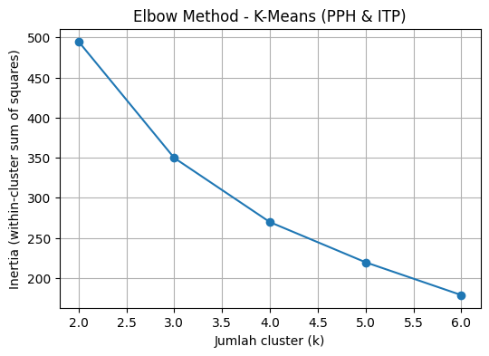

```python
# IMPORT YANG DIBUTUHKAN
from sklearn.cluster import KMeans
from sklearn.metrics import silhouette_score
import matplotlib.pyplot as plt
from sklearn.preprocessing import StandardScaler # Added import for scaling

# Define the features to be used for clustering
fitur = ["Skor_PPH", "IKP"]

# Prepare the data for clustering (using df_tahun from previous steps)
X = df_tahun[fitur].values

# Scale the data
scaler = StandardScaler()
X_scaled = scaler.fit_transform(X)

# 7) Cek beberapa nilai k dengan K-Means
inertias = []
sil_scores = {}

for k in range(2, 7):
    kmeans_tmp = KMeans(
        n_clusters=k,
        n_init=20,
        random_state=42
    )

    # fit & ambil label
    labels_tmp = kmeans_tmp.fit_predict(X_scaled)

    # simpan inertia dan silhouette
    inertia_k = kmeans_tmp.inertia_
    sil_k = silhouette_score(X_scaled, labels_tmp)

    inertias.append((k, inertia_k))
    sil_scores[k] = sil_k

    print(f"k = {k} | inertia = {inertia_k:.2f} | silhouette = {sil_k:.3f}")

# 8) Plot elbow
ks   = [k   for k, _   in inertias]
vals = [val for _, val in inertias]

plt.figure(figsize=(6, 4))
plt.plot(ks, vals, marker="o")
plt.xlabel("Jumlah cluster (k)")
plt.ylabel("Inertia (within-cluster sum of squares)")
plt.title("Elbow Method - K-Means (PPH & ITP)")
plt.grid(True)
plt.show()
```

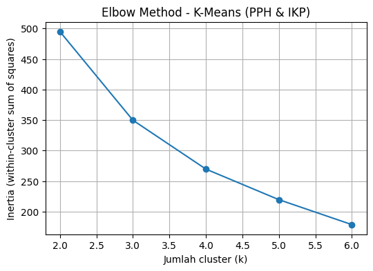

```python
# 8) Plot elbow (opsional)
ks = [k for k, _ in inertias]
vals = [val for _, val in inertias]

plt.figure(figsize=(6,4))
plt.plot(ks, vals, marker="o")
plt.xlabel("Jumlah cluster (k)")
plt.ylabel("Inertia (within-cluster sum of squares)")
plt.title("Elbow Method - K-Means (PPH & IKP)")
plt.grid(True)
plt.show()
```

```python
n_clusters = 4   # ganti sesuai hasil cek di atas
```

```python
# 9) Jalankan K-Means final
kmeans = KMeans(
    n_clusters=n_clusters,
    n_init=50,
    random_state=42
)

# Ensure X_scaled is generated from the current df_tahun
fitur_gizi = ["Skor_PPH", "IKP"]
X = df_tahun[fitur_gizi].values
scaler = StandardScaler()
X_scaled = scaler.fit_transform(X)

cluster_labels_kmeans = kmeans.fit_predict(X_scaled)

df_tahun["cluster_kmeans"] = cluster_labels_kmeans

# 10) Lihat ringkasan rata-rata PPH & IKP per cluster
summary_kmeans = df_tahun.groupby("cluster_kmeans")[fitur_gizi].mean()
print("Rata-rata per cluster (K-Means):")
print(summary_kmeans)
```

```
Rata-rata per cluster (K-Means):
                 Skor_PPH        IKP
cluster_kmeans
0               90.205825  82.507994
1               68.105556  37.062778
2               85.641935  59.710484
3               75.974766  75.471869
```

```python
import numpy as np
import pandas as pd

# --- pilih kolom numerik yang mau diringkas ---
num_cols = ["Skor_PPH", "IKP"]  # tambah nama variabel lain kalau ada

# --- fungsi agregasi yang dipakai ---
agg_funcs = ["mean", "min", "max", "std", "median"]

# --- bikin ringkasan per cluster ---
summary = (
    df_tahun
    .groupby("cluster_kmeans")[num_cols]
    .agg(agg_funcs)
)

# Biar rapi, urutkan cluster
summary = summary.sort_index()

# (opsional) pembulatan
summary = summary.round(3)

summary
```

| cluster_kmeans | Skor_PPH mean | Skor_PPH min | Skor_PPH max | Skor_PPH std | Skor_PPH median | IKP mean | IKP min | IKP max | IKP std | IKP median |
| --- | --- | --- | --- | --- | --- | --- | --- | --- | --- | --- |
| 0 | 90.206 | 81.8 | 98.4 | 3.313 | 90.30 | 82.508 | 68.39 | 96.37 | 5.554 | 82.770 |
| 1 | 68.106 | 43.0 | 88.5 | 10.496 | 68.25 | 37.063 | 14.14 | 56.66 | 12.468 | 37.280 |
| 2 | 85.642 | 75.5 | 95.3 | 4.865 | 85.90 | 59.710 | 40.39 | 71.15 | 7.347 | 60.465 |
| 3 | 75.975 | 55.5 | 83.4 | 5.731 | 77.50 | 75.472 | 59.11 | 87.56 | 6.760 | 76.690 |

🌱 Cluster 0 – “Tahan Pangan & Pola Makan Sangat Baik”

Rata-rata:

Skor_PPH ≈ 90,2 (min 81,8; max 98,4)

IKP ≈ 82,5 (min 68,4; max 96,4)

Interpretasi:

Skor_PPH di atas 90 menunjukkan mutu pola pangan sudah sangat baik dan mendekati komposisi ideal (tidak terlalu didominasi satu kelompok pangan saja, kontribusi pangan hewani dan sayur/buah relatif cukup).

IKP di atas 80 menandakan ketahanan pangan kuat: dari sisi ketersediaan, akses, dan pemanfaatan pangan, wilayah-wilayah di klaster ini tergolong relatif aman.

Sebaran (std kecil) menunjukkan relatif homogen: hampir semua anggota cluster ini sama-sama berada pada level baik–sangat baik.

👉 Narasi: Cluster 0 merepresentasikan kabupaten/kota dengan akses pangan kuat sekaligus pola makan yang sudah beragam dan berkualitas, sehingga risiko kerawanan pangan dan kekurangan gizi relatif rendah. Fokus kebijakan bisa bergeser ke pemantauan transisi gizi dan pencegahan penyakit tidak menular.

🍚 Cluster 1 – “Rentan Pangan & Pola Makan Kurang”

Rata-rata:

Skor_PPH ≈ 68,1 (min 43,0; max 88,5)

IKP ≈ 37,1 (min 14,1; max 56,7)

Interpretasi:

Skor_PPH sekitar 68 menunjukkan mutu pola pangan masih kurang beragam. Energi kemungkinan masih sangat didominasi padi-padian, minyak/gula, sementara pangan hewani dan sayur/buah relatif rendah.

IKP rata-rata hanya sekitar 37 (dengan beberapa wilayah di bawah 20) → ini mengindikasikan tingkat ketahanan pangan rendah / kerentanan tinggi: masalah bisa ada di akses ekonomi, infrastruktur pangan, kemiskinan, dsb.

Standar deviasi IKP cukup besar → ada variasi, tapi mayoritas tetap di kategori rendah.

👉 Narasi: Cluster 1 menggambarkan kabupaten/kota yang menghadapi double problem: secara struktural rentan pangan, dan kualitas pola makan masyarakat juga belum baik. Wilayah ini layak dijadikan prioritas utama intervensi: perbaikan akses & distribusi pangan, pengurangan kemiskinan, plus intervensi edukasi gizi dasar.

🥗 Cluster 2 – “Pola Makan Baik, Ketahanan Pangan Menengah”

Rata-rata:

Skor_PPH ≈ 85,6 (min 75,5; max 95,3)

IKP ≈ 59,7 (min 40,4; max 71,2)

Interpretasi:

Skor_PPH cukup tinggi (mid–high 80an) → pola konsumsi relatif beragam dan menuju ideal. Pangan hewani dan sayur/buah kemungkinan dikonsumsi lebih baik dibanding Cluster 1 & 3.

IKP sekitar 60 → ketahanan pangan pada level sedang: tidak sekuat klaster 0 dan 3, tapi tidak serentan cluster 1. Masih ada beberapa kelemahan struktural.

Ini menarik: meskipun secara ketahanan pangan tidak paling kuat, masyarakatnya masih mampu mempertahankan pola makan yang cukup baik (bisa karena kultur pangan lokal, pemanfaatan pangan non-pasar, dll).

👉 Narasi: Cluster 2 menunjukkan wilayah yang secara struktural masih menengah dalam hal ketahanan pangan, tetapi memiliki pola makan yang relatif baik. Kebijakan yang cocok: penguatan sistem pangan lokal dan ekonomi rumah tangga, sambil menjaga praktik konsumsi yang sudah bagus agar tidak memburuk seiring perubahan ekonomi atau urbanisasi.

🍟 Cluster 3 – “Tahan Pangan tapi Pola Makan Belum Optimal”

Rata-rata:

Skor_PPH ≈ 76,0 (min 55,5; max 83,4)

IKP ≈ 75,5 (min 59,1; max 87,6)

Interpretasi:

IKP ≈ 75 → ketahanan pangan cukup kuat, mendekati cluster 0.

Skor_PPH hanya sekitar 76 → mutu pola pangan masih sedang, masih ada ketidakseimbangan: kemungkinan energi tetap cukup tinggi dari padi-padian/minyak/gula, dan porsi pangan hewani serta sayur/buah belum sebesar cluster 0 & 2.

Artinya: masalah utama bukan lagi akses fisik/economi terhadap pangan, tapi perilaku konsumsi & pilihan jenis pangan.

👉 Narasi: Cluster 3 adalah wilayah yang sudah relatif aman dari sisi ketahanan pangan, namun kualitas pola makan masyarakat belum sepenuhnya mengikuti. Arah kebijakan di klaster ini lebih tepat ke intervensi perilaku dan promosi gizi seimbang (kampanye diversifikasi pangan, pembatasan gula/lemak, peningkatan konsumsi sayur-buah), bukan ke masalah ketersediaan pangan dasar

```python
# dataframe baru berisi identitas + skor + klaster
kolom_identitas = ["Kode Wilayah", "Kabupaten_Kota", "Provinsi", "Tahun"]
kolom_gizi      = ["Skor_PPH", "IKP", "cluster_kmeans"]

df_gizi_cluster = df_tahun[kolom_identitas + kolom_gizi].copy()

df_gizi_cluster
```

|  | Kode Wilayah | Kabupaten_Kota | Provinsi | Tahun | Skor_PPH | IKP | cluster_kmeans |
| --- | --- | --- | --- | --- | --- | --- | --- |
| 0 | 1109 | Kabupaten Simeulue | Aceh | 2024 | 64.3 | 77.54 | 3 |
| 1 | 1110 | Kabupaten Aceh Singkil | Aceh | 2024 | 87.1 | 46.10 | 2 |
| 2 | 1101 | Kabupaten Aceh Selatan | Aceh | 2024 | 74.6 | 73.84 | 3 |
| 3 | 1102 | Kabupaten Aceh Tenggara | Aceh | 2024 | 83.0 | 76.87 | 3 |
| 4 | 1103 | Kabupaten Aceh Timur | Aceh | 2024 | 80.2 | 77.19 | 3 |
| ... | ... | ... | ... | ... | ... | ... | ... |
| 509 | 9405 | Kabupaten Tolikara | Papua Pegunungan | 2024 | 50.5 | 30.12 | 1 |
| 510 | 9406 | Kabupaten Mamberamo Tengah | Papua Pegunungan | 2024 | 53.2 | 31.37 | 1 |
| 511 | 9407 | Kabupaten Yalimo | Papua Pegunungan | 2024 | 81.2 | 14.14 | 1 |
| 512 | 9408 | Kabupaten Yahukimo | Papua Pegunungan | 2024 | 55.6 | 21.35 | 1 |
| 513 | 9171 | Kabupaten Pegunungan Bintang | Papua Pegunungan | 2024 | 72.2 | 78.35 | 3 |

514 rows × 7 columns

```python
import pandas as pd

file_path = "/content/drive/MyDrive/tepege/0_df_long (4).csv"

df = pd.read_csv(file_path, sep=";")  # <== penting: sep=";"

df
```

|  | KabKot | Tahun | Bulan | Produk | Harga | Kategori | KodeBPS | KodeProv | NamaProv |
| --- | --- | --- | --- | --- | --- | --- | --- | --- | --- |
| 0 | Kab. Aceh Barat | 2022 | Januari | Beras Premium | 11429.0 | Beras | 11.05 | 11 | Aceh |
| 1 | Kab. Aceh Barat | 2022 | Januari | Beras Medium | 9979.0 | Beras | 11.05 | 11 | Aceh |
| 2 | Kab. Aceh Barat | 2022 | Januari | Bawang Merah | 31000.0 | Bawang | 11.05 | 11 | Aceh |
| 3 | Kab. Aceh Barat | 2022 | Januari | Bawang Putih (Bonggol) | 28636.0 | Bawang | 11.05 | 11 | Aceh |
| 4 | Kab. Aceh Barat | 2022 | Januari | Cabai Merah Keriting | 19409.0 | Cabai | 11.05 | 11 | Aceh |
| ... | ... | ... | ... | ... | ... | ... | ... | ... | ... |
| 340615 | Kota Yogyakarta | 2025 | Oktober | Minyak Goreng Kemasan | 19100.0 | MinyakGoreng | 34.71 | 34 | DI Yogyakarta |
| 340616 | Kota Yogyakarta | 2025 | Oktober | Minyak Goreng Curah | 17161.0 | MinyakGoreng | 34.71 | 34 | DI Yogyakarta |
| 340617 | Kota Yogyakarta | 2025 | Oktober | Jagung Tk. Peternak | NaN | Jagung | 34.71 | 34 | DI Yogyakarta |
| 340618 | Kota Yogyakarta | 2025 | Oktober | Cabai Merah Besar | 48304.0 | Cabai | 34.71 | 34 | DI Yogyakarta |
| 340619 | Kota Yogyakarta | 2025 | Oktober | Minyakita | 15956.0 | MinyakGoreng | 34.71 | 34 | DI Yogyakarta |

340620 rows × 9 columns

https://ksm.fkik.uin-alauddin.ac.id/artikel-3746-pola-pangan-harapan

```python
import pandas as pd

# misal df sudah dibaca dari CSV
# df = pd.read_csv(file_path, sep=";")

# pastikan tipe datanya numerik dulu
df["Tahun"] = pd.to_numeric(df["Tahun"], errors="coerce")

# ambil hanya tahun 2024
df_2024 = df[df["Tahun"] == 2024].copy()

# cek
df_2024["Tahun"].value_counts()
```

| Tahun | count |
| --- | --- |
| 2024 | 89730 |

**dtype:** int64

```python
df_2024.head()
```

|  | KabKot | Tahun | Bulan | Produk | Harga | Kategori | KodeBPS | KodeProv | NamaProv |
| --- | --- | --- | --- | --- | --- | --- | --- | --- | --- |
| 360 | Kab. Aceh Barat | 2024 | Januari | Beras Premium | 14655.0 | Beras | 11.05 | 11 | Aceh |
| 361 | Kab. Aceh Barat | 2024 | Januari | Beras Medium | 12811.0 | Beras | 11.05 | 11 | Aceh |
| 362 | Kab. Aceh Barat | 2024 | Januari | Bawang Merah | 38386.0 | Bawang | 11.05 | 11 | Aceh |
| 363 | Kab. Aceh Barat | 2024 | Januari | Bawang Putih (Bonggol) | 41636.0 | Bawang | 11.05 | 11 | Aceh |
| 364 | Kab. Aceh Barat | 2024 | Januari | Cabai Merah Keriting | 38523.0 | Cabai | 11.05 | 11 | Aceh |

```python
import pandas as pd
import numpy as np

# 0. SET NAMA KOLOM (SESUAIKAN)

COL_TAHUN   = "Tahun"        # kalau beda, ganti
COL_BULAN   = "Bulan"        # misal "Bulan" atau "month"
COL_PROV    = "NamaProv"     # misal "Provinsi" dll
COL_KAB     = "NamaKabKota"  # misal "KabKota", "KabupatenKota"
COL_PROD    = "Produk"       # nama produk
COL_KAT     = "Kategori"     # kategori (beras, cabai, dll)
COL_HARGA   = "Harga"        # kolom harga

# ==========================================================
# 1. INFO UMUM: bentuk data, tipe, sekilas nilai numerik
# ==========================================================

print("Shape df_2024:", df_2024.shape)
print("\n=== 5 baris pertama ===")
display(df_2024.head())

print("\n=== Info tipe data ===")
df_2024.info()

print("\n=== Ringkasan numerik (kolom numerik saja) ===")
display(df_2024.describe().T)

print("\n=== Ringkasan kategorik (object/categorical) ===")
display(df_2024.describe(include=["object"]).T)
```

```
Shape df_2024: (89730, 9)

=== 5 baris pertama ===
```

|  | KabKot | Tahun | Bulan | Produk | Harga | Kategori | KodeBPS | KodeProv | NamaProv |
| --- | --- | --- | --- | --- | --- | --- | --- | --- | --- |
| 360 | Kab. Aceh Barat | 2024 | Januari | Beras Premium | 14655.0 | Beras | 11.05 | 11 | Aceh |
| 361 | Kab. Aceh Barat | 2024 | Januari | Beras Medium | 12811.0 | Beras | 11.05 | 11 | Aceh |
| 362 | Kab. Aceh Barat | 2024 | Januari | Bawang Merah | 38386.0 | Bawang | 11.05 | 11 | Aceh |
| 363 | Kab. Aceh Barat | 2024 | Januari | Bawang Putih (Bonggol) | 41636.0 | Bawang | 11.05 | 11 | Aceh |
| 364 | Kab. Aceh Barat | 2024 | Januari | Cabai Merah Keriting | 38523.0 | Cabai | 11.05 | 11 | Aceh |

```
=== Info tipe data ===
<class 'pandas.core.frame.DataFrame'>
Index: 89730 entries, 360 to 340469
Data columns (total 9 columns):
 #   Column    Non-Null Count  Dtype
---  ------    --------------  -----
 0   KabKot    89730 non-null  object
 1   Tahun     89730 non-null  int64
 2   Bulan     89730 non-null  object
 3   Produk    89730 non-null  object
 4   Harga     72546 non-null  float64
 5   Kategori  89730 non-null  object
 6   KodeBPS   89730 non-null  float64
 7   KodeProv  89730 non-null  int64
 8   NamaProv  88830 non-null  object
dtypes: float64(2), int64(2), object(5)
memory usage: 6.8+ MB

=== Ringkasan numerik (kolom numerik saja) ===
```

|  | count | mean | std | min | 25% | 50% | 75% | max |
| --- | --- | --- | --- | --- | --- | --- | --- | --- |
| Tahun | 89730.0 | 2024.000000 | 0.000000 | 2024.00 | 2024.00 | 2024.00 | 2024.00 | 2024.00 |
| Harga | 72546.0 | 37114.463527 | 33144.433524 | 3000.00 | 16540.00 | 27517.00 | 41233.75 | 200000.00 |
| KodeBPS | 89730.0 | 44.206332 | 25.706404 | 11.01 | 17.71 | 35.23 | 71.04 | 92.71 |
| KodeProv | 89730.0 | 43.993982 | 25.742891 | 11.00 | 17.00 | 35.00 | 71.00 | 92.00 |

```
=== Ringkasan kategorik (object/categorical) ===
```

|  | count | unique | top | freq |
| --- | --- | --- | --- | --- |
| KabKot | 89730 | 503 | Kota Yogyakarta | 180 |
| Bulan | 89730 | 12 | September | 7500 |
| Produk | 89730 | 15 | Beras Premium | 5982 |
| Kategori | 89730 | 7 | Cabai | 17946 |
| NamaProv | 88830 | 33 | Jawa Timur | 6840 |

```python
# 2. CEK MISSING VALUE

missing_counts = df_2024.isna().sum()
missing_pct = df_2024.isna().mean() * 100

missing_df = (
    pd.concat([missing_counts, missing_pct], axis=1)
    .rename(columns={0: "n_missing", 1: "pct_missing"})
    .sort_values("pct_missing", ascending=False)
)

print("\n=== Missing value per kolom ===")
display(missing_df.style.format({"pct_missing": "{:.2f}%"}))

# Fokus khusus ke kolom harga
if COL_HARGA in df_2024.columns:
    print("\n=== Ringkasan kolom Harga (termasuk NA) ===")
    display(df_2024[COL_HARGA].describe())
    print("\nJumlah NA di kolom Harga:", df_2024[COL_HARGA].isna().sum())
```

```
=== Missing value per kolom ===
```

|  | n_missing | pct_missing |
| --- | --- | --- |
| Harga | 17184 | 19.15% |
| NamaProv | 900 | 1.00% |
| KabKot | 0 | 0.00% |
| Bulan | 0 | 0.00% |
| Tahun | 0 | 0.00% |
| Produk | 0 | 0.00% |
| Kategori | 0 | 0.00% |
| KodeBPS | 0 | 0.00% |
| KodeProv | 0 | 0.00% |

```
=== Ringkasan kolom Harga (termasuk NA) ===
```

|  | Harga |
| --- | --- |
| count | 72546.000000 |
| mean | 37114.463527 |
| std | 33144.433524 |
| min | 3000.000000 |
| 25% | 16540.000000 |
| 50% | 27517.000000 |
| 75% | 41233.750000 |
| max | 200000.000000 |

**dtype:** float64

```
Jumlah NA di kolom Harga: 17184
```

Temuan:

- Harga punya 17.184 NA ≈ 19,1% → lumayan banyak, wajib di-handle.
- NamaProv cuma 1% NA → bisa gampang diisi dari KodeProv.
- Harga:std ≈ 33.144 → sebaran sangat lebar, right-skewed (buntut kanan panjang).
- Implikasi untuk klaster gizi: Fitur utama kita adalah harga, jadi: NA wajib diimputasi Atasi dengan wilayah yang terdekat rata-rata harga

```python
# ==========================================================
# 3. JUMLAH KATEGORI UTAMA (produk, kategori, prov, kab)
# ==========================================================

print("\n=== Jumlah unik beberapa kolom penting ===")
for c in [COL_PROD, COL_KAT, COL_PROV, COL_KAB]:
    if c in df_2024.columns:
        print(f"{c}: {df_2024[c].nunique()} unik")

print("\n=== Contoh daftar Produk ===")
if COL_PROD in df_2024.columns:
    display(df_2024[COL_PROD].dropna().unique())

print("\n=== Contoh daftar Kategori ===")
if COL_KAT in df_2024.columns:
    display(df_2024[COL_KAT].dropna().unique())

print("\n=== Contoh daftar Provinsi ===")
if COL_PROV in df_2024.columns:
    display(df_2024[COL_PROV].dropna().unique()[:20])  # tampilkan 20 pertama
```

```
=== Jumlah unik beberapa kolom penting ===
Produk: 15 unik
Kategori: 7 unik
NamaProv: 33 unik

=== Contoh daftar Produk ===
```

```
array(['Beras Premium', 'Beras Medium', 'Bawang Merah',
       'Bawang Putih (Bonggol)', 'Cabai Merah Keriting',
       'Cabai Rawit Merah', 'Daging Sapi Murni', 'Daging Ayam Ras',
       'Telur Ayam Ras', 'Gula Konsumsi', 'Minyak Goreng Kemasan',
       'Minyak Goreng Curah', 'Jagung Tk. Peternak', 'Cabai Merah Besar',
       'Minyakita'], dtype=object)
```

```
=== Contoh daftar Kategori ===
```

```
array(['Beras', 'Bawang', 'Cabai', 'Protein', 'Gula', 'MinyakGoreng',
       'Jagung'], dtype=object)
```

```
=== Contoh daftar Provinsi ===
```

```
array(['Aceh', 'Sumatera Barat', 'Nusa Tenggara Timur', 'Sumatera Utara',
       'Bali', 'Kalimantan Selatan', 'Jawa Barat', 'Sulawesi Tengah',
       'Kepulauan Bangka Belitung', 'Jawa Timur', 'Jawa Tengah',
       'Sulawesi Selatan', 'DI Yogyakarta', 'Sumatera Selatan',
       'Kalimantan Tengah', 'Jambi', 'Riau', 'Kalimantan Barat',
       'Bengkulu', 'Kalimantan Timur'], dtype=object)
```

Temuan:

- Produk = 15, Kategori = 7, NamaProv = 33.
- Produk: beras premium/medium, minyak goreng, gula, bawang, cabai, daging, telur, jagung.
- Kategori: Beras, Bawang, Cabai, Gula, MinyakGoreng, Jagung, Protein.
- Implikasi untuk klaster gizi: 15 produk → mapping ke 5 kategori gizi:Karbohidrat (Beras, Jagung); ProteinHewani (Daging, Telur); LemakMinyak (Minyak goreng, Minyakita);Gula; SayurBumbu (Bawang, Cabai)
- 33 provinsi → nanti bisa dipakai buat peta klaster, dan cek apakah cluster “mahal” memang banyak di timur/daerah tertinggal.

```python
# ==========================================================
# 4. DISTRIBUSI HARGA PER PRODUK & PER KATEGORI
# ==========================================================

# Harga per Produk
if all(col in df_2024.columns for col in [COL_PROD, COL_HARGA]):
    harga_produk = (
        df_2024
        .groupby(COL_PROD)[COL_HARGA]
        .agg(["count", "mean", "std", "min", "max"])
        .sort_values("mean")
    )
    print("\n=== Ringkasan Harga per Produk (2024) ===")
    display(harga_produk.style.format("{:,.0f}"))

# Harga per Kategori
if all(col in df_2024.columns for col in [COL_KAT, COL_HARGA]):
    harga_kat = (
        df_2024
        .groupby(COL_KAT)[COL_HARGA]
        .agg(["count", "mean", "std", "min", "max"])
        .sort_values("mean")
    )
    print("\n=== Ringkasan Harga per Kategori (2024) ===")
    display(harga_kat.style.format("{:,.0f}"))
```

```
=== Ringkasan Harga per Produk (2024) ===
```

| Produk | count | mean | std | min | max |
| --- | --- | --- | --- | --- | --- |
| Jagung Tk. Peternak | 2,964 | 7,472 | 3,347 | 3,000 | 50,000 |
| Beras Medium | 5,950 | 13,840 | 2,157 | 10,000 | 53,218 |
| Beras Premium | 5,982 | 15,827 | 2,560 | 12,000 | 63,218 |
| Minyak Goreng Curah | 5,181 | 16,196 | 1,775 | 10,000 | 25,000 |
| Gula Konsumsi | 5,975 | 18,092 | 2,160 | 13,935 | 50,000 |
| Minyak Goreng Kemasan | 5,948 | 18,292 | 3,094 | 13,500 | 50,000 |
| Telur Ayam Ras | 5,976 | 30,000 | 5,965 | 21,576 | 85,000 |
| Bawang Merah | 5,973 | 37,358 | 11,646 | 10,000 | 113,148 |
| Daging Ayam Ras | 5,973 | 37,541 | 7,894 | 20,581 | 85,000 |
| Bawang Putih (Bonggol) | 5,952 | 41,602 | 7,484 | 27,241 | 113,148 |
| Cabai Merah Keriting | 5,837 | 47,174 | 17,726 | 12,625 | 150,000 |
| Cabai Rawit Merah | 5,254 | 53,704 | 20,078 | 14,000 | 174,818 |
| Daging Sapi Murni | 5,581 | 136,308 | 15,646 | 95,000 | 200,000 |
| Cabai Merah Besar | 0 | nan | nan | nan | nan |
| Minyakita | 0 | nan | nan | nan | nan |

```
=== Ringkasan Harga per Kategori (2024) ===
```

| Kategori | count | mean | std | min | max |
| --- | --- | --- | --- | --- | --- |
| Jagung | 2,964 | 7,472 | 3,347 | 3,000 | 50,000 |
| Beras | 11,932 | 14,836 | 2,568 | 10,000 | 63,218 |
| MinyakGoreng | 11,129 | 17,316 | 2,770 | 10,000 | 50,000 |
| Gula | 5,975 | 18,092 | 2,160 | 13,935 | 50,000 |
| Bawang | 11,925 | 39,476 | 10,019 | 10,000 | 113,148 |
| Cabai | 11,091 | 50,267 | 19,156 | 12,625 | 174,818 |
| Protein | 17,530 | 66,414 | 49,018 | 20,581 | 200,000 |

```python
# ==========================================================
# 5. PRODUK vs KATEGORI (cek konsistensi)
# ==========================================================

if all(col in df_2024.columns for col in [COL_PROD, COL_KAT]):
    print("\n=== Crosstab Produk x Kategori (banyaknya baris) ===")
    ctab_pk = pd.crosstab(df_2024[COL_PROD], df_2024[COL_KAT])
    display(ctab_pk)
```

```
=== Crosstab Produk x Kategori (banyaknya baris) ===
```

| Kategori Produk | Bawang | Beras | Cabai | Gula | Jagung | MinyakGoreng | Protein |
| --- | --- | --- | --- | --- | --- | --- | --- |
| Bawang Merah | 5982 | 0 | 0 | 0 | 0 | 0 | 0 |
| Bawang Putih (Bonggol) | 5982 | 0 | 0 | 0 | 0 | 0 | 0 |
| Beras Medium | 0 | 5982 | 0 | 0 | 0 | 0 | 0 |
| Beras Premium | 0 | 5982 | 0 | 0 | 0 | 0 | 0 |
| Cabai Merah Besar | 0 | 0 | 5982 | 0 | 0 | 0 | 0 |
| Cabai Merah Keriting | 0 | 0 | 5982 | 0 | 0 | 0 | 0 |
| Cabai Rawit Merah | 0 | 0 | 5982 | 0 | 0 | 0 | 0 |
| Daging Ayam Ras | 0 | 0 | 0 | 0 | 0 | 0 | 5982 |
| Daging Sapi Murni | 0 | 0 | 0 | 0 | 0 | 0 | 5982 |
| Gula Konsumsi | 0 | 0 | 0 | 5982 | 0 | 0 | 0 |
| Jagung Tk. Peternak | 0 | 0 | 0 | 0 | 5982 | 0 | 0 |
| Minyak Goreng Curah | 0 | 0 | 0 | 0 | 0 | 5982 | 0 |
| Minyak Goreng Kemasan | 0 | 0 | 0 | 0 | 0 | 5982 | 0 |
| Minyakita | 0 | 0 | 0 | 0 | 0 | 5982 | 0 |
| Telur Ayam Ras | 0 | 0 | 0 | 0 | 0 | 0 | 5982 |

Temuan:

- Masing-masing produk hanya muncul di 1 kategori:Bawang Merah ↔ Bawang;Gula Konsumsi ↔ Gula; Daging Sapi Murni ↔ Protein; dst.
- Count tiap sel = 5982 → artinya setiap produk punya jumlah baris yang sama, indikasi: Panelnya rapi: 5982 baris ≈ 503 kab/kota × 12 bulan untuk 1 produk.
- Implikasi untuk klaster gizi: Kategori di file konsisten, nggak ada produk “nyasar”.
- Memudahkan agregasi:bisa agregasi per Kategori atau langsung per KategoriGizi tanpa takut produk double-count.

```python
# ==========================================================
# 6. SEBARAN HARGA MENURUT PROVINSI
# ==========================================================

if all(col in df_2024.columns for col in [COL_PROV, COL_HARGA]):
    harga_prov = (
        df_2024
        .groupby(COL_PROV)[COL_HARGA]
        .agg(["count", "mean", "std", "min", "max"])
        .sort_values("mean")
    )
    print("\n=== Ringkasan Harga per Provinsi (2024) ===")
    display(harga_prov.head(10).style.format("{:,.0f}"))   # 10 prov termurah
    print("\n=== 10 Provinsi dengan rata-rata harga tertinggi ===")
    display(harga_prov.tail(10).style.format("{:,.0f}"))

# ==========================================================
# 7. SEBARAN HARGA MENURUT BULAN (MUSIMAN)
# ==========================================================

if all(col in df_2024.columns for col in [COL_BULAN, COL_HARGA]):
    harga_bulan = (
        df_2024
        .groupby(COL_BULAN)[COL_HARGA]
        .agg(["count", "mean", "std", "min", "max"])
        .sort_values("mean")
    )
    print("\n=== Ringkasan Harga per Bulan (2024) ===")
    display(harga_bulan.style.format("{:,.0f}"))
```

```
=== Ringkasan Harga per Provinsi (2024) ===
```

| NamaProv | count | mean | std | min | max |
| --- | --- | --- | --- | --- | --- |
| Sulawesi Selatan | 3,613 | 30,754 | 27,752 | 3,000 | 150,000 |
| Bali | 1,339 | 31,294 | 25,901 | 4,700 | 120,000 |
| Jawa Timur | 5,652 | 31,781 | 28,045 | 4,064 | 141,094 |
| Sumatera Utara | 4,562 | 32,775 | 29,637 | 3,966 | 176,905 |
| Jawa Tengah | 5,332 | 33,429 | 30,993 | 4,000 | 145,179 |
| Sulawesi Barat | 868 | 33,744 | 27,924 | 4,345 | 137,897 |
| DI Yogyakarta | 741 | 34,492 | 32,614 | 4,050 | 145,804 |
| Nusa Tenggara Barat | 1,495 | 34,817 | 28,790 | 3,600 | 129,074 |
| Lampung | 2,251 | 34,884 | 32,324 | 3,252 | 150,000 |
| Jambi | 1,548 | 35,382 | 32,539 | 5,548 | 154,375 |

```
=== 10 Provinsi dengan rata-rata harga tertinggi ===
```

| NamaProv | count | mean | std | min | max |
| --- | --- | --- | --- | --- | --- |
| DKI Jakarta | 830 | 39,621 | 32,104 | 11,700 | 149,643 |
| Kalimantan Timur | 1,490 | 40,842 | 37,023 | 6,655 | 170,806 |
| Maluku | 1,583 | 41,127 | 30,083 | 5,000 | 174,818 |
| Kepulauan Bangka Belitung | 968 | 41,482 | 35,513 | 10,000 | 153,519 |
| Kalimantan Barat | 2,044 | 42,920 | 38,636 | 4,629 | 170,909 |
| Kepulauan Riau | 1,004 | 43,187 | 39,448 | 6,000 | 180,000 |
| Kalimantan Tengah | 2,048 | 43,406 | 39,356 | 6,000 | 180,000 |
| Papua | 1,606 | 45,250 | 33,625 | 5,192 | 160,000 |
| Maluku Utara | 1,398 | 46,721 | 33,863 | 6,984 | 160,000 |
| Papua Barat | 2,309 | 54,842 | 41,695 | 6,000 | 200,000 |

```
=== Ringkasan Harga per Bulan (2024) ===
```

| Bulan | count | mean | std | min | max |
| --- | --- | --- | --- | --- | --- |
| Oktober | 5,994 | 34,918 | 32,402 | 3,820 | 180,000 |
| November | 5,995 | 35,155 | 32,176 | 3,000 | 180,000 |
| September | 6,017 | 35,214 | 32,879 | 3,733 | 180,192 |
| Desember | 6,006 | 36,564 | 32,201 | 3,854 | 180,000 |
| Agustus | 6,033 | 36,953 | 33,679 | 3,252 | 200,000 |
| Januari | 6,130 | 37,283 | 33,476 | 5,000 | 200,000 |
| Juli | 6,039 | 37,413 | 33,386 | 3,384 | 200,000 |
| Februari | 6,099 | 37,738 | 33,348 | 5,000 | 200,000 |
| Mei | 6,078 | 38,195 | 33,113 | 3,943 | 197,778 |
| Juni | 6,026 | 38,572 | 33,590 | 3,542 | 200,000 |
| Maret | 6,080 | 38,592 | 33,502 | 4,781 | 200,000 |
| April | 6,049 | 38,711 | 33,614 | 4,000 | 200,000 |

Temuan:

- 10 provinsi dengan rata-rata harga terendah: Sulawesi Selatan, Bali, Jawa Timur, Sumatera Utara, Jawa Tengah, Sulbar, DIY, NTB, Lampung, Jambi dengan Mean mereka sekitar 30–34k.
- 10 provinsi dengan rata-rata harga tertinggi: DKI Jakarta, Kalimantan Timur, Maluku, Kep. Bangka Belitung, Kalimantan Barat, Kep. Riau, Kalimantan Tengah, Papua, Maluku Utara, Papua Barat dengan Mean mereka sekitar 40–45k+.
- Pola klasik muncul: Provinsi di Jawa & beberapa Sulawesi cenderung lebih murah; DKI, Kalimantan, Maluku, Papua cenderung mahal → mungkin karena biaya logistik, struktur pasar, dsb.
- Implikasi untuk klaster gizi: Kita bisa mengantisipasi bahwa: Cluster “harga tinggi” akan banyak berisi kab/kota dari DKI, Kaltim, Papua, dll;Cluster “harga rendah” akan banyak dari Jawa & sebagian Sumatera/Sulawesi.
- Kalau cluster gizi yang “rentan” (PPH/IKP rendah) ternyata cocok dengan provinsi yang mahal → narasi makin kuat.
- Rata-rata harga per bulan 2024 berkisar 34,9k – 38,7k: paling rendah: Oktober (34,9k), November & September juga agak rendah; tertinggi: April (38,7k).
- Selisih antar bulan nggak terlalu besar (bandingkan dengan variasi antar produk/provinsi).
- Implikasi untuk klaster gizi: Variasi horizontal (antar bulan) relatif kecil dibanding variansi vertikal (antar produk & kabupaten/provinsi).
- Untuk tujuan klaster struktur gizi per kab/kota: cukup pakai rata-rata tahunan 2024 → kamu tidak perlu time-series clustering complicated. Ini menghemat dimensi dan membuat interpretasi jauh lebih simple.

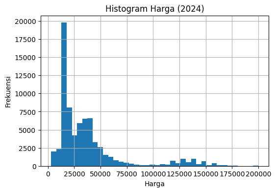

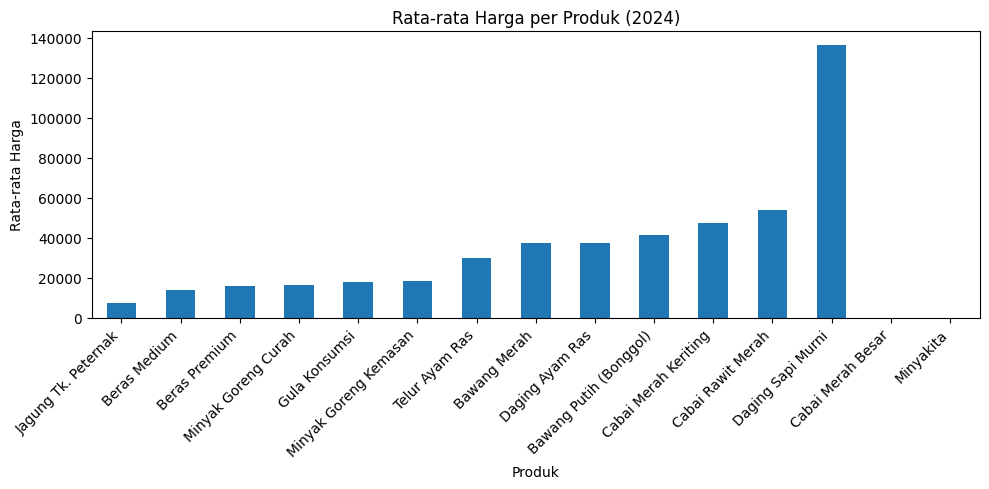

```python
import matplotlib.pyplot as plt

# Histogram harga
if COL_HARGA in df_2024.columns:
    plt.figure(figsize=(6,4))
    df_2024[COL_HARGA].dropna().hist(bins=40)
    plt.xlabel("Harga")
    plt.ylabel("Frekuensi")
    plt.title("Histogram Harga (2024)")
    plt.show()

# Rata-rata harga per produk (barplot)
if all(col in df_2024.columns for col in [COL_PROD, COL_HARGA]):
    mean_prod = (
        df_2024
        .groupby(COL_PROD)[COL_HARGA]
        .mean()
        .sort_values()
    )
    plt.figure(figsize=(10,5))
    mean_prod.plot(kind="bar")
    plt.ylabel("Rata-rata Harga")
    plt.title("Rata-rata Harga per Produk (2024)")
    plt.xticks(rotation=45, ha="right")
    plt.tight_layout()
    plt.show()
```

Temuan:

- Histogram: Distribusi highly right-skewed: banyak observasi di 10–40 ribu, buntut panjang sampai 200 ribu.
- Barplot rata-rata per produk: Jagung paling murah, disusul beras, minyak, gula; lalu bawang/cabai; puncak super tinggi di Daging Sapi Murni.
- Implikasi untuk klaster gizi: Sekali lagi menegaskan: ProteinHewani adalah kategori paling “berat di kantong”. Ini bakal jadi kunci: cluster dengan Harga_Protein tinggi mungkin berkaitan dengan: skor PPH rendah (pangan hewani kurang), atau IKP rendah (akses ekonomi terbatas).
- Skewness: gunakan scaling (standardization atau log-transform) sebelum K-means/K-medoids.

```python
# STEP 1. BERESIN NamaProv
# =========================

# pastikan KodeProv numerik (bisa juga dijadikan string kalau mau)
df_2024["KodeProv"] = pd.to_numeric(df_2024["KodeProv"], errors="coerce")

# buat mapping KodeProv -> NamaProv dari baris yang NamaProv-nya tidak NA
prov_map = (
    df_2024
    .dropna(subset=["NamaProv"])
    .drop_duplicates(subset=["KodeProv"])[["KodeProv", "NamaProv"]]
    .set_index("KodeProv")["NamaProv"]
)

# isi NamaProv yang kosong pakai mapping
df_2024["NamaProv"] = df_2024["NamaProv"].fillna(
    df_2024["KodeProv"].map(prov_map)
)

print("Sisa NA di NamaProv:", df_2024["NamaProv"].isna().sum())
```

```
Sisa NA di NamaProv: 900
```

```python
# cek KodeProv di baris yang NamaProv-nya masih NA
df_2024.loc[df_2024["NamaProv"].isna(), "KodeProv"].unique()
```

```
array([65])
```

```python
# lihat beberapa contoh baris yang NamaProv-nya NA
df_2024.loc[df_2024["NamaProv"].isna(), ["KabKot", "KodeBPS", "KodeProv"]].head(20)
```

|  | KabKot | KodeBPS | KodeProv |
| --- | --- | --- | --- |
| 51525 | Kab. Bulungan | 65.01 | 65 |
| 51526 | Kab. Bulungan | 65.01 | 65 |
| 51527 | Kab. Bulungan | 65.01 | 65 |
| 51528 | Kab. Bulungan | 65.01 | 65 |
| 51529 | Kab. Bulungan | 65.01 | 65 |
| 51530 | Kab. Bulungan | 65.01 | 65 |
| 51531 | Kab. Bulungan | 65.01 | 65 |
| 51532 | Kab. Bulungan | 65.01 | 65 |
| 51533 | Kab. Bulungan | 65.01 | 65 |
| 51534 | Kab. Bulungan | 65.01 | 65 |
| 51535 | Kab. Bulungan | 65.01 | 65 |
| 51536 | Kab. Bulungan | 65.01 | 65 |
| 51537 | Kab. Bulungan | 65.01 | 65 |
| 51538 | Kab. Bulungan | 65.01 | 65 |
| 51539 | Kab. Bulungan | 65.01 | 65 |
| 51540 | Kab. Bulungan | 65.01 | 65 |
| 51541 | Kab. Bulungan | 65.01 | 65 |
| 51542 | Kab. Bulungan | 65.01 | 65 |
| 51543 | Kab. Bulungan | 65.01 | 65 |
| 51544 | Kab. Bulungan | 65.01 | 65 |

```python
# manual mapping untuk provinsi yang belum kebaca dari data
manual_prov_map = {
    65: "Kalimantan Utara"
}

df_2024["NamaProv"] = df_2024["NamaProv"].fillna(
    df_2024["KodeProv"].map(manual_prov_map)
)

print("Sisa NA di NamaProv (setelah manual isi):",
      df_2024["NamaProv"].isna().sum())
```

```
Sisa NA di NamaProv (setelah manual isi): 0
```

```python
# ===========================
# Level 0: Inisialisasi kolom imputasi
# ===========================
if "Harga_imputed" not in df_2024.columns:
    df_2024["Harga_imputed"] = df_2024["Harga"].copy()

# ===========================
# Level 1: Imputasi per provinsi (Tahun, Bulan, Produk)
# ===========================
mask_na = df_2024["Harga_imputed"].isna()

if mask_na.any():
    group_col1 = ["Tahun", "Bulan", "NamaProv", "Produk"]
    prov_mean = df_2024.groupby(group_col1)["Harga"].transform("mean")
    df_2024.loc[mask_na, "Harga_imputed"] = prov_mean[mask_na]

print(
    "Sisa NA setelah imputasi provinsi (tahun+bulan+prov+produk):",
    df_2024["Harga_imputed"].isna().sum()
)

# ===========================
# Level 2: Imputasi nasional per (Tahun, Bulan, Produk)
# ===========================
mask_na = df_2024["Harga_imputed"].isna()

if mask_na.any():
    group_col2 = ["Tahun", "Bulan", "Produk"]
    nat_mean = df_2024.groupby(group_col2)["Harga"].transform("mean")
    df_2024.loc[mask_na, "Harga_imputed"] = nat_mean[mask_na]

print(
    "Sisa NA setelah imputasi nasional (tahun+bulan+produk):",
    df_2024["Harga_imputed"].isna().sum()
)

# ===========================
# Level 3: Imputasi nasional per (Tahun, Produk)
# ===========================
mask_na = df_2024["Harga_imputed"].isna()

if mask_na.any():
    group_col3 = ["Tahun", "Produk"]
    prod_mean = df_2024.groupby(group_col3)["Harga"].transform("mean")
    df_2024.loc[mask_na, "Harga_imputed"] = prod_mean[mask_na]

print(
    "Sisa NA setelah imputasi nasional (produk):",
    df_2024["Harga_imputed"].isna().sum()
)
```

```
Sisa NA setelah imputasi provinsi (tahun+bulan+prov+produk): 12390
Sisa NA setelah imputasi nasional (tahun+bulan+produk): 11964
Sisa NA setelah imputasi nasional (produk): 11964
```

```python
# hanya baris yang masih NA di Harga_imputed setelah step 3
mask_na_final = df_2024["Harga"].isna()

df_2024.loc[mask_na_final, ["Produk", "Kategori"]].value_counts()
```

| Produk | Kategori | count |
| --- | --- | --- |
| Cabai Merah Besar | Cabai | 5982 |
| Minyakita | MinyakGoreng | 5982 |
| Jagung Tk. Peternak | Jagung | 3018 |
| Minyak Goreng Curah | MinyakGoreng | 801 |
| Cabai Rawit Merah | Cabai | 728 |
| Daging Sapi Murni | Protein | 401 |
| Cabai Merah Keriting | Cabai | 145 |
| Minyak Goreng Kemasan | MinyakGoreng | 34 |
| Beras Medium | Beras | 32 |
| Bawang Putih (Bonggol) | Bawang | 30 |
| Bawang Merah | Bawang | 9 |
| Daging Ayam Ras | Protein | 9 |
| Gula Konsumsi | Gula | 7 |
| Telur Ayam Ras | Protein | 6 |

**dtype:** int64

```python
import pandas as pd
import numpy as np

# 0. BACA DATA & SUBSET 2024
# ============================================================

# GANTI path ini sesuai lokasi file-mu
file_path = "/content/drive/MyDrive/tepege/0_df_long (4).csv"

df = pd.read_csv(file_path, sep=";")

# kolom yang kita pakai
cols_keep = ["KabKot", "Tahun", "Bulan", "Produk",
             "Harga", "Kategori", "KodeBPS", "KodeProv", "NamaProv"]
df = df[cols_keep].copy()

# pastikan Tahun numerik & ambil 2024 saja
df["Tahun"] = pd.to_numeric(df["Tahun"], errors="coerce")
df_2024 = df[df["Tahun"] == 2024].copy()

print("Shape df_2024:", df_2024.shape)
print(df_2024.head())
```

```
Shape df_2024: (89730, 9)
              KabKot  Tahun    Bulan                  Produk    Harga  \
360  Kab. Aceh Barat   2024  Januari           Beras Premium  14655.0
361  Kab. Aceh Barat   2024  Januari            Beras Medium  12811.0
362  Kab. Aceh Barat   2024  Januari            Bawang Merah  38386.0
363  Kab. Aceh Barat   2024  Januari  Bawang Putih (Bonggol)  41636.0
364  Kab. Aceh Barat   2024  Januari    Cabai Merah Keriting  38523.0

    Kategori  KodeBPS  KodeProv NamaProv
360    Beras    11.05        11     Aceh
361    Beras    11.05        11     Aceh
362   Bawang    11.05        11     Aceh
363   Bawang    11.05        11     Aceh
364    Cabai    11.05        11     Aceh
```

```python
# 1. BERESIN NamaProv
#    (supaya imputasi per provinsi jelas)
# ============================================================

df_2024["KodeProv"] = pd.to_numeric(df_2024["KodeProv"], errors="coerce")

# mapping otomatis KodeProv -> NamaProv dari baris yang terisi
prov_map_auto = (
    df_2024
    .dropna(subset=["NamaProv"])
    .drop_duplicates(subset=["KodeProv"])[["KodeProv", "NamaProv"]]
    .set_index("KodeProv")["NamaProv"]
)

df_2024["NamaProv"] = df_2024["NamaProv"].fillna(
    df_2024["KodeProv"].map(prov_map_auto)
)

# kalau masih ada NA (misal Kalimantan Utara, kode 65), isi manual
manual_prov_map = {
    65: "Kalimantan Utara"
}

df_2024["NamaProv"] = df_2024["NamaProv"].fillna(
    df_2024["KodeProv"].map(manual_prov_map)
)

print("Sisa NA di NamaProv:", df_2024["NamaProv"].isna().sum())
```

```
Sisa NA di NamaProv: 0
```

```python
# ============================================================
# 2. IMPUTASI HARGA (NA)
#    Wilayah terdekat = provinsi
# ============================================================

df_2024["Harga"] = pd.to_numeric(df_2024["Harga"], errors="coerce")

# kolom kerja harga
df_2024["Harga_imputed"] = df_2024["Harga"]

# --- Level 1: rata-rata per (Tahun, Bulan, Produk, KodeProv) ---
group_cols1 = ["Tahun", "Bulan", "Produk", "KodeProv"]
prov_mean = df_2024.groupby(group_cols1)["Harga"].transform("mean")

mask_na = df_2024["Harga_imputed"].isna()
df_2024.loc[mask_na, "Harga_imputed"] = prov_mean[mask_na]

print("Sisa NA setelah imputasi provinsi:",
      df_2024["Harga_imputed"].isna().sum())
```

```
Sisa NA setelah imputasi provinsi: 12390
```

```python
# --- Level 2: rata-rata nasional per (Tahun, Bulan, Produk) ---
mask_na = df_2024["Harga_imputed"].isna()
if mask_na.any():
    group_cols2 = ["Tahun", "Bulan", "Produk"]
    nat_mean = df_2024.groupby(group_cols2)["Harga"].transform("mean")
    df_2024.loc[mask_na, "Harga_imputed"] = nat_mean[mask_na]

print("Sisa NA setelah imputasi nasional (bulan-produk):",
      df_2024["Harga_imputed"].isna().sum())
```

```
Sisa NA setelah imputasi nasional (bulan-produk): 11964
```

```python
# --- Level 3: rata-rata nasional per (Tahun, Produk) ---
mask_na = df_2024["Harga_imputed"].isna()
if mask_na.any():
    group_cols3 = ["Tahun", "Produk"]
    prod_mean = df_2024.groupby(group_cols3)["Harga"].transform("mean")
    df_2024.loc[mask_na, "Harga_imputed"] = prod_mean[mask_na]

print("Sisa NA setelah imputasi nasional (produk):", df_2024["Harga_imputed"].isna().sum())
```

```
Sisa NA setelah imputasi nasional (produk): 11964
```

```python
# ============================================================
# 2b. DROP PRODUK YANG 100% TIDAK PUNYA HARGA (CABAI BESAR, MINYAKITA)
# ============================================================

na_stats = (
    df_2024
      .assign(is_na=df_2024["Harga_imputed"].isna())
      .groupby("Produk")["is_na"]
      .agg(sum_na="sum", n_total="count")
)

print("\nNA stats per produk:")
display(na_stats)

produk_full_na = na_stats[na_stats["sum_na"] == na_stats["n_total"]].index.tolist()
print("Produk yang 100% NA dan akan di-drop:", produk_full_na)

# drop produk itu
if len(produk_full_na) > 0:
    df_2024 = df_2024[~df_2024["Produk"].isin(produk_full_na)].copy()

# kalau masih ada NA sisa (sedikit banget), isi pakai mean global 2024
mask_na = df_2024["Harga_imputed"].isna()
if mask_na.any():
    global_mean = df_2024["Harga_imputed"].mean()
    df_2024.loc[mask_na, "Harga_imputed"] = global_mean

# jadikan Harga final
df_2024["Harga"] = df_2024["Harga_imputed"]
df_2024.drop(columns=["Harga_imputed"], inplace=True)

print("Total NA di Harga (final):", df_2024["Harga"].isna().sum())
```

```
NA stats per produk:
```

| Produk | sum_na | n_total |
| --- | --- | --- |
| Bawang Merah | 0 | 5982 |
| Bawang Putih (Bonggol) | 0 | 5982 |
| Beras Medium | 0 | 5982 |
| Beras Premium | 0 | 5982 |
| Cabai Merah Besar | 5982 | 5982 |
| Cabai Merah Keriting | 0 | 5982 |
| Cabai Rawit Merah | 0 | 5982 |
| Daging Ayam Ras | 0 | 5982 |
| Daging Sapi Murni | 0 | 5982 |
| Gula Konsumsi | 0 | 5982 |
| Jagung Tk. Peternak | 0 | 5982 |
| Minyak Goreng Curah | 0 | 5982 |
| Minyak Goreng Kemasan | 0 | 5982 |
| Minyakita | 5982 | 5982 |
| Telur Ayam Ras | 0 | 5982 |

```
Produk yang 100% NA dan akan di-drop: ['Cabai Merah Besar', 'Minyakita']
Total NA di Harga (final): 0
```

```python
# STEP 3. BUAT KATEGORI GIZI BARU
# ==================================

gizi_by_produk = {
    "Beras Premium"          : "Karbohidrat",
    "Beras Medium"           : "Karbohidrat",
    "Jagung Tk. Peternak"    : "Karbohidrat",

    "Daging Ayam Ras"        : "ProteinHewani",
    "Daging Sapi Murni"      : "ProteinHewani",
    "Telur Ayam Ras"         : "ProteinHewani",

    "Minyak Goreng Curah"    : "LemakMinyak",
    "Minyak Goreng Kemasan"  : "LemakMinyak",
    "Minyakita"              : "LemakMinyak",   # 2024 count 0, tapi ga masalah

    "Gula Konsumsi"          : "Gula",

    "Bawang Merah"           : "SayurBumbu",
    "Bawang Putih (Bonggol)" : "SayurBumbu",
    "Cabai Merah Keriting"   : "SayurBumbu",
    "Cabai Rawit Merah"      : "SayurBumbu",
    "Cabai Merah Besar"      : "SayurBumbu",    # 2024 count 0
}

df_2024["KategoriGizi"] = df_2024["Produk"].map(gizi_by_produk)

print("\nCek KategoriGizi (termasuk NA kalau ada):")
print(df_2024["KategoriGizi"].value_counts(dropna=False))

# kalau ada produk yang belum ter-mapping, cek di sini
produk_unmapped = df_2024[df_2024["KategoriGizi"].isna()]["Produk"].unique()
if len(produk_unmapped) > 0:
    print("\nWARNING: ada produk belum ter-mapping:", produk_unmapped)
```

```
Cek KategoriGizi (termasuk NA kalau ada):
KategoriGizi
SayurBumbu       23928
Karbohidrat      17946
ProteinHewani    17946
LemakMinyak      11964
Gula              5982
Name: count, dtype: int64
```

```python
# STEP 4. AGREGASI KE LEVEL KAB/KOTA (2024)
# ============================================

# pakai hanya baris yang KategoriGizi-nya sudah jelas
df_gizi = df_2024.dropna(subset=["KategoriGizi"]).copy()

# groupby KabKot x KategoriGizi (plus identitas provinsi)
agg = (
    df_gizi
    .groupby(["KabKot", "NamaProv", "KodeProv", "KategoriGizi","KodeBPS"])["Harga"]
    .mean()
    .reset_index()
)

# pivot: 1 baris per kab/kota, kolom = kategori gizi
fitur_kab_2024 = (
    agg
    .pivot_table(index=["KabKot", "NamaProv", "KodeProv","KodeBPS"],
                 columns="KategoriGizi",
                 values="Harga")
    .reset_index()
)

# rename kolom biar jelas
fitur_kab_2024 = fitur_kab_2024.rename(columns={
    "Karbohidrat"   : "Harga_Karbohidrat",
    "ProteinHewani" : "Harga_ProteinHewani",
    "LemakMinyak"   : "Harga_LemakMinyak",
    "Gula"          : "Harga_Gula",
    "SayurBumbu"    : "Harga_SayurBumbu"
})

# pastikan tipe numerik
harga_cols = [
    "Harga_Karbohidrat",
    "Harga_ProteinHewani",
    "Harga_LemakMinyak",
    "Harga_Gula",
    "Harga_SayurBumbu"
]
for col in harga_cols:
    fitur_kab_2024[col] = pd.to_numeric(fitur_kab_2024[col], errors="coerce")

print("\nJumlah kab/kota di fitur_kab_2024:", fitur_kab_2024.shape[0])
print("Cek NA per kolom fitur:")
print(fitur_kab_2024[harga_cols].isna().sum())
```

```
Jumlah kab/kota di fitur_kab_2024: 503
Cek NA per kolom fitur:
KategoriGizi
Harga_Karbohidrat      0
Harga_ProteinHewani    0
Harga_LemakMinyak      0
Harga_Gula             0
Harga_SayurBumbu       0
dtype: int64
```

```python
fitur_kab_2024.head()
```

| KategoriGizi | KabKot | NamaProv | KodeProv | KodeBPS | Harga_Gula | Harga_Karbohidrat | Harga_LemakMinyak | Harga_ProteinHewani | Harga_SayurBumbu |
| --- | --- | --- | --- | --- | --- | --- | --- | --- | --- |
| 0 | Kab. Aceh Barat | Aceh | 11 | 11.05 | 18294.416667 | 12151.287037 | 17447.833333 | 67892.083333 | 43154.770833 |
| 1 | Kab. Aceh Barat Daya | Aceh | 11 | 11.12 | 18360.666667 | 11850.805556 | 14670.208333 | 74303.944444 | 39652.450694 |
| 2 | Kab. Aceh Besar | Aceh | 11 | 11.06 | 18180.250000 | 11871.444444 | 17588.458333 | 68744.472222 | 39652.179861 |
| 3 | Kab. Aceh Jaya | Aceh | 11 | 11.14 | 18735.000000 | 12154.824074 | 17295.958333 | 68611.388889 | 42720.117361 |
| 4 | Kab. Aceh Selatan | Aceh | 11 | 11.01 | 17401.333333 | 12197.444444 | 16416.750000 | 75417.894180 | 39980.700694 |

```python
import pandas as pd
import numpy as np
from sklearn.preprocessing import StandardScaler
from sklearn.cluster import KMeans
from sklearn.metrics import silhouette_score
from scipy.stats import kruskal

# =========================
# 1) SCALING
# =========================

harga_cols = [
    "Harga_Karbohidrat",
    "Harga_ProteinHewani",
    "Harga_LemakMinyak",
    "Harga_Gula",
    "Harga_SayurBumbu"
]

# matriks fitur
X = fitur_harga_2024[harga_cols].values

# standardisasi
scaler = StandardScaler()
X_scaled = scaler.fit_transform(X)

print("=== Ringkasan X_scaled (harus mean≈0, std≈1) ===")
X_scaled_df = pd.DataFrame(X_scaled, columns=[c + "_scaled" for c in harga_cols])
print(X_scaled_df.describe().T)

# simpan kolom scaled ke dataframe utama (optional tapi enak buat cek)
for i, col in enumerate(harga_cols):
    fitur_harga_2024[col + "_scaled"] = X_scaled[:, i]

print("\n=== Cek beberapa baris kolom scaled ===")
display(fitur_harga_2024[[c + "_scaled" for c in harga_cols]].head())
```

[output not shown]

```python
from sklearn.cluster import KMeans
from sklearn.metrics import silhouette_score

results = []

for k in range(2, 9):   # coba 2 s/d 8 cluster
    km = KMeans(
        n_clusters=k,
        random_state=42,
        n_init=20
    )
    labels = km.fit_predict(X_scaled)
    inertia = km.inertia_

    # silhouette butuh minimal 2 cluster
    sil = silhouette_score(X_scaled, labels)

    results.append((k, inertia, sil))

results_df = pd.DataFrame(results, columns=["k", "inertia", "silhouette"])
results_df
```

|  | k | inertia | silhouette |
| --- | --- | --- | --- |
| 0 | 2 | 494.948306 | 0.560425 |
| 1 | 3 | 349.784945 | 0.450382 |
| 2 | 4 | 269.727439 | 0.460171 |
| 3 | 5 | 219.656006 | 0.373558 |
| 4 | 6 | 178.797811 | 0.385255 |
| 5 | 7 | 152.195984 | 0.393714 |
| 6 | 8 | 133.830427 | 0.342940 |

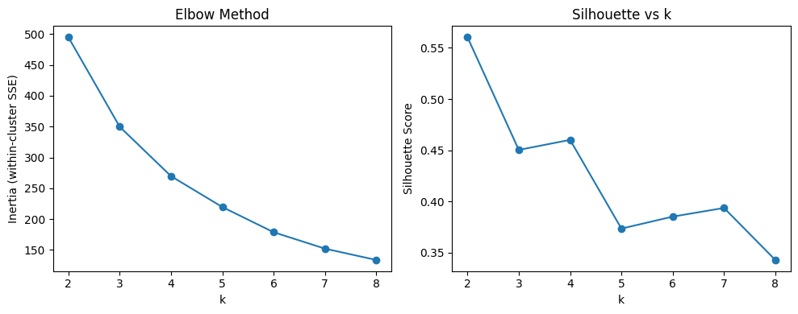

```python
import matplotlib.pyplot as plt

plt.figure(figsize=(10,4))
plt.subplot(1,2,1)
plt.plot(results_df["k"], results_df["inertia"], marker="o")
plt.xlabel("k")
plt.ylabel("Inertia (within-cluster SSE)")
plt.title("Elbow Method")

plt.subplot(1,2,2)
plt.plot(results_df["k"], results_df["silhouette"], marker="o")
plt.xlabel("k")
plt.ylabel("Silhouette Score")
plt.title("Silhouette vs k")

plt.tight_layout()
plt.show()
```

```python
# =========================
# 2) K-MEANS PAKAI DATA SCALED
# =========================

k_opt = 3  # dari hasil elbow + silhouette

kmeans = KMeans(
    n_clusters=k_opt,
    random_state=42,
    n_init=20
)

# --- ENSURE X_SCALED IS FOR THE CURRENT fitur_harga_2024 ---
harga_cols_for_clustering = [
    "Harga_Karbohidrat",
    "Harga_ProteinHewani",
    "Harga_LemakMinyak",
    "Harga_Gula",
    "Harga_SayurBumbu"
]
X_price = fitur_kab_2024[harga_cols_for_clustering].values
scaler_price = StandardScaler() # Create a new scaler for price data
X_scaled_price = scaler_price.fit_transform(X_price)

cluster_labels = kmeans.fit_predict(X_scaled_price) # Use X_scaled_price here
fitur_kab_2024["Cluster_KMeans"] = cluster_labels

print("\n=== Jumlah anggota per cluster (KMeans) ===")
print(fitur_kab_2024["Cluster_KMeans"].value_counts().sort_index())
```

```
=== Jumlah anggota per cluster (KMeans) ===
Cluster_KMeans
0    392
1      7
2    104
Name: count, dtype: int64
```

```python
# =========================
# 3) CENTROIDS: SCALED vs ASLI
# =========================

centroids_scaled = kmeans.cluster_centers_
centroids_orig = scaler_price.inverse_transform(centroids_scaled) # Changed scaler to scaler_price

centroids_scaled_df = pd.DataFrame(
    centroids_scaled,
    columns=[c + "_scaled" for c in harga_cols]
)
centroids_scaled_df["cluster"] = centroids_scaled_df.index

centroids_orig_df = pd.DataFrame(
    centroids_orig,
    columns=harga_cols
)
centroids_orig_df["cluster"] = centroids_orig_df.index

print("\n=== Centroid di ruang SCALED ===")
display(centroids_scaled_df.round(3))

print("\n=== Centroid di ruang ASLI (satuan harga) ===")
display(centroids_orig_df.round(0))
```

```
=== Centroid di ruang SCALED ===
```

|  | Harga_Karbohidrat_scaled | Harga_ProteinHewani_scaled | Harga_LemakMinyak_scaled | Harga_Gula_scaled | Harga_SayurBumbu_scaled | cluster |
| --- | --- | --- | --- | --- | --- | --- |
| 0 | -0.284 | -0.359 | -0.305 | -0.226 | -0.390 | 0 |
| 1 | 6.085 | 4.170 | 5.487 | 7.227 | 5.101 | 1 |
| 2 | 0.660 | 1.073 | 0.782 | 0.365 | 1.126 | 2 |

```
=== Centroid di ruang ASLI (satuan harga) ===
```

|  | Harga_Karbohidrat | Harga_ProteinHewani | Harga_LemakMinyak | Harga_Gula | Harga_SayurBumbu | cluster |
| --- | --- | --- | --- | --- | --- | --- |
| 0 | 11795.0 | 65487.0 | 16746.0 | 17647.0 | 40893.0 | 0 |
| 1 | 25543.0 | 98706.0 | 29050.0 | 34507.0 | 99650.0 | 1 |
| 2 | 13831.0 | 75987.0 | 19056.0 | 18984.0 | 57115.0 | 2 |

```python
# =========================
# 4) SUMMARY PER CLUSTER
#    (SCALED vs ASLI)
# =========================

# Re-add scaled columns to fitur_kab_2024 if they don't exist
# This step is needed because the previous cell that was supposed to add them might have failed.
if len([c for c in harga_cols if c + "_scaled" in fitur_kab_2024.columns]) < len(harga_cols):
    for i, col in enumerate(harga_cols):
        fitur_kab_2024[col + "_scaled"] = X_scaled_price[:, i]

# summary di ruang scaled
scaled_cols = [c + "_scaled" for c in harga_cols]
profile_scaled = fitur_kab_2024.groupby("Cluster_KMeans")[scaled_cols] \
    .agg(["mean", "median", "std"]).round(3)

print("\n=== RINGKASAN PER CLUSTER (RUANG SCALED) ===")
display(profile_scaled)

# summary di ruang asli
profile_orig = fitur_kab_2024.groupby("Cluster_KMeans")[harga_cols] \
    .agg(["mean", "median", "std", "count", "min", "max"]).round(0)

print("\n=== RINGKASAN PER CLUSTER (RUANG ASLI, SATUAN HARGA) ===")
display(profile_orig)
```

```
=== RINGKASAN PER CLUSTER (RUANG SCALED) ===
```

| KategoriGizi Cluster_KMeans | Harga_Karbohidrat_scaled mean | Harga_Karbohidrat_scaled median | Harga_Karbohidrat_scaled std | Harga_ProteinHewani_scaled mean | Harga_ProteinHewani_scaled median | Harga_ProteinHewani_scaled std | Harga_LemakMinyak_scaled mean | Harga_LemakMinyak_scaled median | Harga_LemakMinyak_scaled std | Harga_Gula_scaled mean | Harga_Gula_scaled median | Harga_Gula_scaled std | Harga_SayurBumbu_scaled mean | Harga_SayurBumbu_scaled median | Harga_SayurBumbu_scaled std |
| --- | --- | --- | --- | --- | --- | --- | --- | --- | --- | --- | --- | --- | --- | --- | --- |
| 0 | -0.284 | -0.336 | 0.334 | -0.359 | -0.338 | 0.588 | -0.305 | -0.373 | 0.466 | -0.226 | -0.237 | 0.314 | -0.390 | -0.409 | 0.399 |
| 1 | 6.085 | 4.278 | 3.959 | 4.170 | 5.009 | 1.547 | 5.487 | 5.023 | 1.256 | 7.227 | 6.957 | 2.503 | 5.101 | 5.332 | 1.095 |
| 2 | 0.660 | 0.634 | 0.534 | 1.073 | 1.081 | 0.773 | 0.782 | 0.655 | 0.974 | 0.365 | 0.376 | 0.516 | 1.126 | 1.045 | 0.764 |

```
=== RINGKASAN PER CLUSTER (RUANG ASLI, SATUAN HARGA) ===
```

| KategoriGizi Cluster_KMeans | Harga_Karbohidrat mean | Harga_Karbohidrat median | Harga_Karbohidrat std | Harga_Karbohidrat count | Harga_Karbohidrat min | Harga_Karbohidrat max | Harga_ProteinHewani mean | Harga_ProteinHewani median | Harga_ProteinHewani std | Harga_ProteinHewani count | ... | Harga_Gula std | Harga_Gula count | Harga_Gula min | Harga_Gula max | Harga_SayurBumbu mean | Harga_SayurBumbu median | Harga_SayurBumbu std | Harga_SayurBumbu count | Harga_SayurBumbu min | Harga_SayurBumbu max |
| --- | --- | --- | --- | --- | --- | --- | --- | --- | --- | --- | --- | --- | --- | --- | --- | --- | --- | --- | --- | --- | --- |
| 0 | 11795.0 | 11682.0 | 721.0 | 392 | 10404.0 | 14145.0 | 65487.0 | 65641.0 | 4312.0 | 392 | ... | 710.0 | 392 | 15042.0 | 20739.0 | 40893.0 | 40683.0 | 4268.0 | 392 | 30619.0 | 52815.0 |
| 1 | 25543.0 | 21642.0 | 8545.0 | 7 | 16913.0 | 40402.0 | 98706.0 | 104859.0 | 11347.0 | 7 | ... | 5662.0 | 7 | 28804.0 | 43178.0 | 99650.0 | 102129.0 | 11721.0 | 7 | 77253.0 | 112500.0 |
| 2 | 13831.0 | 13777.0 | 1152.0 | 104 | 11163.0 | 19244.0 | 75987.0 | 76048.0 | 5671.0 | 104 | ... | 1168.0 | 104 | 15768.0 | 23788.0 | 57115.0 | 56244.0 | 8172.0 | 104 | 38409.0 | 76282.0 |

3 rows × 30 columns

```python
# =========================
# 5) UJI KRUSKAL–WALLIS
# =========================

print("\n=== Uji Kruskal–Wallis per variabel (pakai harga ASLI) ===")
for col in harga_cols:
    groups = [g[col].values for _, g in fitur_kab_2024.groupby("Cluster_KMeans")]
    stat, p = kruskal(*groups)
    print(f"{col:>18}  H={stat:.3f}, p={p:.2e}")
```

```
=== Uji Kruskal–Wallis per variabel (pakai harga ASLI) ===
 Harga_Karbohidrat  H=208.094, p=6.50e-46
Harga_ProteinHewani  H=200.288, p=3.22e-44
 Harga_LemakMinyak  H=138.943, p=6.74e-31
        Harga_Gula  H=143.005, p=8.85e-32
  Harga_SayurBumbu  H=235.383, p=7.71e-52
```

Hasil uji Kruskal–Wallis menunjukkan bahwa untuk seluruh kelompok komoditas pangan (karbohidrat, protein hewani, lemak/minyak, gula, sayur-bumbu) terdapat perbedaan yang signifikan antar klaster (p < 0,001). Hal ini mengindikasikan bahwa klaster yang dibentuk oleh K-Means memang memisahkan kabupaten/kota berdasarkan pola harga pangan yang berbeda, bukan sekadar variasi acak.

```python
# =========================
# 6) DUNN POST-HOC
# =========================

!pip install scikit-posthocs -q
import scikit_posthocs as sp

posthoc_dict = {}

for col in harga_cols:
    data = fitur_kab_2024[[col, "Cluster_KMeans"]].dropna()
    pvals = sp.posthoc_dunn(
        data,
        val_col=col,
        group_col="Cluster_KMeans",
        p_adjust="holm"   # koreksi multipel Holm
    )
    posthoc_dict[col] = pvals
    print(f"\n=== Dunn post-hoc (Holm) untuk {col} ===")
    display(pvals.round(4))
```

```
=== Dunn post-hoc (Holm) untuk Harga_Karbohidrat ===
```

|  | 0 | 1 | 2 |
| --- | --- | --- | --- |
| 0 | 1.0 | 0.0000 | 0.0000 |
| 1 | 0.0 | 1.0000 | 0.1709 |
| 2 | 0.0 | 0.1709 | 1.0000 |

```
=== Dunn post-hoc (Holm) untuk Harga_ProteinHewani ===
```

|  | 0 | 1 | 2 |
| --- | --- | --- | --- |
| 0 | 1.0 | 0.0000 | 0.0000 |
| 1 | 0.0 | 1.0000 | 0.1638 |
| 2 | 0.0 | 0.1638 | 1.0000 |

```
=== Dunn post-hoc (Holm) untuk Harga_LemakMinyak ===
```

|  | 0 | 1 | 2 |
| --- | --- | --- | --- |
| 0 | 1.0 | 0.0000 | 0.0000 |
| 1 | 0.0 | 1.0000 | 0.0451 |
| 2 | 0.0 | 0.0451 | 1.0000 |

```
=== Dunn post-hoc (Holm) untuk Harga_Gula ===
```

|  | 0 | 1 | 2 |
| --- | --- | --- | --- |
| 0 | 1.0 | 0.0000 | 0.0000 |
| 1 | 0.0 | 1.0000 | 0.0498 |
| 2 | 0.0 | 0.0498 | 1.0000 |

```
=== Dunn post-hoc (Holm) untuk Harga_SayurBumbu ===
```

|  | 0 | 1 | 2 |
| --- | --- | --- | --- |
| 0 | 1.0 | 0.000 | 0.000 |
| 1 | 0.0 | 1.000 | 0.246 |
| 2 | 0.0 | 0.246 | 1.000 |

```python
# lihat distribusi
print(fitur_kab_2024["Cluster_KMeans"].value_counts().sort_index())

# tampilkan contoh baris untuk cluster kecil (misal label yang punya count kecil)
for c in fitur_kab_2024["Cluster_KMeans"].value_counts().index:
    print("Cluster", c, "n=", fitur_kab_2024["Cluster_KMeans"].value_counts()[c])
    display(fitur_kab_2024.loc[fitur_kab_2024["Cluster_KMeans"]==c].head(10))
```

```
Cluster_KMeans
0    392
1      7
2    104
Name: count, dtype: int64
Cluster 0 n= 392
```

| KategoriGizi | KabKot | NamaProv | KodeProv | KodeBPS | Harga_Gula | Harga_Karbohidrat | Harga_LemakMinyak | Harga_ProteinHewani | Harga_SayurBumbu | Cluster_KMeans | Harga_Karbohidrat_scaled | Harga_ProteinHewani_scaled | Harga_LemakMinyak_scaled | Harga_Gula_scaled | Harga_SayurBumbu_scaled |
| --- | --- | --- | --- | --- | --- | --- | --- | --- | --- | --- | --- | --- | --- | --- | --- |
| 0 | Kab. Aceh Barat | Aceh | 11 | 11.05 | 18294.416667 | 12151.287037 | 17447.833333 | 67892.083333 | 43154.770833 | 0 | -0.118741 | -0.031123 | 0.024808 | 0.060292 | -0.178466 |
| 1 | Kab. Aceh Barat Daya | Aceh | 11 | 11.12 | 18360.666667 | 11850.805556 | 14670.208333 | 74303.944444 | 39652.450694 | 0 | -0.257948 | 0.843105 | -1.282918 | 0.089578 | -0.505739 |
| 2 | Kab. Aceh Besar | Aceh | 11 | 11.06 | 18180.250000 | 11871.444444 | 17588.458333 | 68744.472222 | 39652.179861 | 0 | -0.248386 | 0.085096 | 0.091016 | 0.009826 | -0.505764 |
| 3 | Kab. Aceh Jaya | Aceh | 11 | 11.14 | 18735.000000 | 12154.824074 | 17295.958333 | 68611.388889 | 42720.117361 | 0 | -0.117102 | 0.066951 | -0.046695 | 0.255048 | -0.219082 |
| 4 | Kab. Aceh Selatan | Aceh | 11 | 11.01 | 17401.333333 | 12197.444444 | 16416.750000 | 75417.894180 | 39980.700694 | 0 | -0.097357 | 0.994987 | -0.460633 | -0.334486 | -0.475065 |
| 5 | Kab. Aceh Singkil | Aceh | 11 | 11.10 | 17939.500000 | 12710.027778 | 15535.666667 | 72256.993927 | 39506.659028 | 0 | 0.140111 | 0.564013 | -0.875454 | -0.096595 | -0.519362 |
| 6 | Kab. Aceh Tamiang | Aceh | 11 | 11.16 | 18035.250000 | 11634.138889 | 14770.791667 | 63399.361111 | 39875.488889 | 0 | -0.358325 | -0.643686 | -1.235563 | -0.054270 | -0.484897 |
| 7 | Kab. Aceh Tengah | Aceh | 11 | 11.04 | 18109.333333 | 12264.222222 | 16524.083333 | 72354.777778 | 39498.163194 | 0 | -0.066421 | 0.577345 | -0.410100 | -0.021522 | -0.520156 |
| 8 | Kab. Aceh Tenggara | Aceh | 11 | 11.02 | 18021.916667 | 11545.777778 | 18331.166667 | 69812.388889 | 37549.700694 | 0 | -0.399261 | 0.230702 | 0.440688 | -0.060163 | -0.702229 |
| 9 | Kab. Aceh Timur | Aceh | 11 | 11.03 | 17683.583333 | 12039.916667 | 17508.208333 | 70500.166667 | 40295.179861 | 0 | -0.170337 | 0.324477 | 0.053233 | -0.209720 | -0.445679 |

```
Cluster 2 n= 104
```

| KategoriGizi | KabKot | NamaProv | KodeProv | KodeBPS | Harga_Gula | Harga_Karbohidrat | Harga_LemakMinyak | Harga_ProteinHewani | Harga_SayurBumbu | Cluster_KMeans | Harga_Karbohidrat_scaled | Harga_ProteinHewani_scaled | Harga_LemakMinyak_scaled | Harga_Gula_scaled | Harga_SayurBumbu_scaled |
| --- | --- | --- | --- | --- | --- | --- | --- | --- | --- | --- | --- | --- | --- | --- | --- |
| 19 | Kab. Banggai Kepulauan | Sulawesi Tengah | 72 | 72.07 | 20077.333333 | 12842.000000 | 18068.696338 | 70743.250000 | 50253.000000 | 2 | 0.201251 | 0.357621 | 0.317115 | 0.848413 | 0.484825 |
| 20 | Kab. Banggai Laut | Sulawesi Tengah | 72 | 72.11 | 19740.666667 | 12652.805556 | 17643.570076 | 73379.055556 | 56241.812500 | 2 | 0.113602 | 0.717001 | 0.116963 | 0.699593 | 1.044447 |
| 35 | Kab. Barito Selatan | Kalimantan Tengah | 62 | 62.04 | 17772.250000 | 13088.215939 | 15445.750000 | 77788.194444 | 51098.437500 | 2 | 0.315318 | 1.318167 | -0.917787 | -0.170526 | 0.563827 |
| 36 | Kab. Barito Timur | Kalimantan Tengah | 62 | 62.13 | 17602.916667 | 13477.049272 | 17088.833333 | 79042.305556 | 53195.395833 | 2 | 0.495456 | 1.489160 | -0.144211 | -0.245378 | 0.759776 |
| 37 | Kab. Barito Utara | Kalimantan Tengah | 62 | 62.05 | 18061.750000 | 13200.666667 | 16543.416667 | 79162.444444 | 60254.000000 | 2 | 0.367414 | 1.505540 | -0.400998 | -0.042556 | 1.419364 |
| 48 | Kab. Bengkayang | Kalimantan Barat | 61 | 61.07 | 18058.333333 | 13068.484193 | 18269.041667 | 80034.491453 | 50874.854167 | 2 | 0.306177 | 1.624440 | 0.411439 | -0.044066 | 0.542934 |
| 52 | Kab. Berau | Kalimantan Timur | 64 | 64.03 | 18996.333333 | 14999.888889 | 19588.916667 | 77555.083333 | 59168.916667 | 2 | 1.200955 | 1.286384 | 1.032846 | 0.370568 | 1.317969 |
| 53 | Kab. Biak Numfor | Papua Barat | 91 | 91.06 | 19252.333333 | 14504.836806 | 19299.029101 | 74600.361111 | 57049.687500 | 2 | 0.971608 | 0.883520 | 0.896365 | 0.483730 | 1.119938 |
| 74 | Kab. Bulungan | Kalimantan Utara | 65 | 65.01 | 19021.083333 | 13491.466944 | 17884.958333 | 79062.861111 | 62907.187500 | 2 | 0.502136 | 1.491962 | 0.230610 | 0.381508 | 1.667290 |
| 78 | Kab. Buru Selatan | Maluku | 81 | 81.09 | 19731.666667 | 14775.925926 | 20841.916667 | 72006.265432 | 58878.062500 | 2 | 1.097198 | 0.529827 | 1.622768 | 0.695614 | 1.290790 |

```
Cluster 1 n= 7
```

| KategoriGizi | KabKot | NamaProv | KodeProv | KodeBPS | Harga_Gula | Harga_Karbohidrat | Harga_LemakMinyak | Harga_ProteinHewani | Harga_SayurBumbu | Cluster_KMeans | Harga_Karbohidrat_scaled | Harga_ProteinHewani_scaled | Harga_LemakMinyak_scaled | Harga_Gula_scaled | Harga_SayurBumbu_scaled |
| --- | --- | --- | --- | --- | --- | --- | --- | --- | --- | --- | --- | --- | --- | --- | --- |
| 121 | Kab. Intan Jaya | Papua Barat | 91 | 91.27 | 43177.988889 | 40401.774746 | 31713.137434 | 105185.520370 | 102128.643440 | 1 | 12.969105 | 5.053669 | 6.741019 | 11.059824 | 5.332322 |
| 123 | Kab. Jayawijaya | Papua Barat | 91 | 91.02 | 28803.916667 | 21641.839561 | 26492.904101 | 89959.944444 | 77253.041667 | 1 | 4.278029 | 2.977731 | 4.283295 | 4.705911 | 3.007832 |
| 255 | Kab. Nduga | Papua Barat | 91 | 91.24 | 33896.000000 | 16912.646104 | 27128.690909 | 81817.363636 | 93189.478896 | 1 | 2.087095 | 1.867526 | 4.582628 | 6.956815 | 4.497005 |
| 305 | Kab. Puncak | Papua Barat | 91 | 91.25 | 40000.000000 | 32222.000000 | 32003.000000 | 111666.666667 | 112500.000000 | 1 | 9.179590 | 5.937344 | 6.877489 | 9.655026 | 6.301468 |
| 306 | Kab. Puncak Jaya | Papua Barat | 91 | 91.07 | 36620.333333 | 28453.700672 | 31774.070767 | 107751.777778 | 105788.349330 | 1 | 7.433818 | 5.403567 | 6.769707 | 8.161079 | 5.674301 |
| 402 | Kab. Yahukimo | Papua Barat | 91 | 91.13 | 29445.034722 | 20918.996399 | 26177.043761 | 89700.111332 | 108069.157804 | 1 | 3.943151 | 2.942303 | 4.134585 | 4.989310 | 5.887430 |
| 403 | Kab. Yalimo | Papua Barat | 91 | 91.22 | 29605.125000 | 18251.500000 | 28063.995238 | 104859.166667 | 98619.843750 | 1 | 2.707357 | 5.009172 | 5.022976 | 5.060077 | 5.004443 |

📌 Cluster 0 — Wilayah dengan Harga Pangan Relatif Rendah dan Stabil

- Jumlah kabupaten/kota: 392
- Ciri utama:
1. Hampir semua kelompok harga (karbohidrat, protein hewani, minyak, gula, sayur-bumbu) berada pada level paling rendah dibanding dua klaster lainnya.
2. Penyebaran harga (std) kecil → harga lebih stabil dan homogen antar wilayah.
3. Detail pola: Harga Karbohidrat: median sekitar 11.682, jauh lebih rendah dari cluster 1 & 2; Harga Protein Hewani: median sekitar 65.641, juga paling rendah; Harga Sayur-Bumbu: median sekitar 40.683, masih yang terendah.

Kesimpulan: Cluster 0 menggambarkan wilayah dengan akses harga pangan yang relatif terjangkau dan pasar yang stabil. Ini dapat mencerminkan daerah dengan pasokan yang baik, distribusi yang lancar, atau biaya logistik yang lebih rendah.

📌 Cluster 1 — Wilayah dengan Harga Sangat Mahal (Outlier Cluster)

- Jumlah kabupaten/kota: 7 saja (sangat sedikit)
- Ciri utama:
1. Hampir semua harga berada pada level tertinggi di semua variabel.
2. Varians juga besar (std tinggi) → harga tidak stabil, bergejolak.
3. Karena anggotanya sedikit, cluster ini merupakan outlier ekonomi/harga.
4. Detail pola: Harga Karbohidrat: median 21.642, hampir dua kali lipat Cluster 0; Harga Protein Hewani: median 104.859, paling tinggi dari semua; Harga Sayur-Bumbu: median 102.129, juga tertinggi.

Kesimpulan: Cluster 1 merepresentasikan wilayah dengan harga-harga sangat mahal, kemungkinan akibat akses logistik sulit, wilayah kepulauan, jarak jauh dari pusat distribusi, atau pasar dengan suplai terbatas. Cluster ini adalah wilayah prioritas intervensi bila tujuan analisis adalah stabilisasi harga atau pemerataan akses pangan.

📌 Cluster 2 — Wilayah dengan Harga Sedang (Middle Cluster)

- Jumlah kabupaten/kota: 104
- Ciri utama:
1. Harga berada di tengah-tengah antara Cluster 0 dan Cluster 1.
2. tabilitas harga lebih baik daripada cluster 1, tetapi tidak setinggi cluster 0.
3. Mewakili wilayah dengan kondisi pasar menengah.
4. Detail pola: Harga Karbohidrat median 13.777, masih terjangkau tapi lebih mahal dari cluster 0; Harga Protein Hewani median 76.048, menengah; Harga Sayur-Bumbu median 56.244, berada di tengah juga.

Kesimpulan: Cluster ini adalah wilayah dengan harga moderat, tidak terlalu murah tetapi juga bukan wilayah dengan beban harga ekstrem. Biasanya wilayah ini memiliki kondisi logistik yang cukup baik tetapi tidak sekuat cluster 0.

```python
fitur_kab_2024["Cluster_KMeans_HargaGizi"] = kmeans.labels_
fitur_kab_2024
```

| KategoriGizi | KabKot | NamaProv | KodeProv | KodeBPS | Harga_Gula | Harga_Karbohidrat | Harga_LemakMinyak | Harga_ProteinHewani | Harga_SayurBumbu | Cluster_KMeans | Harga_Karbohidrat_scaled | Harga_ProteinHewani_scaled | Harga_LemakMinyak_scaled | Harga_Gula_scaled | Harga_SayurBumbu_scaled | Cluster_KMeans_HargaGizi |
| --- | --- | --- | --- | --- | --- | --- | --- | --- | --- | --- | --- | --- | --- | --- | --- | --- |
| 0 | Kab. Aceh Barat | Aceh | 11 | 11.05 | 18294.416667 | 12151.287037 | 17447.833333 | 67892.083333 | 43154.770833 | 0 | -0.118741 | -0.031123 | 0.024808 | 0.060292 | -0.178466 | 0 |
| 1 | Kab. Aceh Barat Daya | Aceh | 11 | 11.12 | 18360.666667 | 11850.805556 | 14670.208333 | 74303.944444 | 39652.450694 | 0 | -0.257948 | 0.843105 | -1.282918 | 0.089578 | -0.505739 | 0 |
| 2 | Kab. Aceh Besar | Aceh | 11 | 11.06 | 18180.250000 | 11871.444444 | 17588.458333 | 68744.472222 | 39652.179861 | 0 | -0.248386 | 0.085096 | 0.091016 | 0.009826 | -0.505764 | 0 |
| 3 | Kab. Aceh Jaya | Aceh | 11 | 11.14 | 18735.000000 | 12154.824074 | 17295.958333 | 68611.388889 | 42720.117361 | 0 | -0.117102 | 0.066951 | -0.046695 | 0.255048 | -0.219082 | 0 |
| 4 | Kab. Aceh Selatan | Aceh | 11 | 11.01 | 17401.333333 | 12197.444444 | 16416.750000 | 75417.894180 | 39980.700694 | 0 | -0.097357 | 0.994987 | -0.460633 | -0.334486 | -0.475065 | 0 |
| ... | ... | ... | ... | ... | ... | ... | ... | ... | ... | ... | ... | ... | ... | ... | ... | ... |
| 498 | Kota Ternate | Maluku Utara | 82 | 82.71 | 19320.500000 | 14575.736111 | 20388.277778 | 72862.527778 | 62824.645833 | 2 | 1.004454 | 0.646575 | 1.409192 | 0.513862 | 1.659577 | 2 |
| 499 | Kota Tidore Kepulauan | Maluku Utara | 82 | 82.72 | 19481.250000 | 14570.375000 | 19707.486111 | 79201.583333 | 61878.145833 | 2 | 1.001971 | 1.510876 | 1.088670 | 0.584920 | 1.571132 | 2 |
| 500 | Kota Tomohon | Sulawesi Utara | 71 | 71.73 | 18465.916667 | 11642.694444 | 16747.666667 | 65494.583333 | 44835.937500 | 0 | -0.354361 | -0.358011 | -0.304835 | 0.136102 | -0.021370 | 0 |
| 501 | Kota Tual | Maluku | 81 | 81.72 | 17820.916667 | 13111.750000 | 17435.608631 | 73902.361111 | 51772.708333 | 2 | 0.326221 | 0.788351 | 0.019053 | -0.149014 | 0.626833 | 2 |
| 502 | Kota Yogyakarta | DI Yogyakarta | 34 | 34.71 | 17086.666667 | 11367.208333 | 15868.958333 | 64223.833333 | 35116.270833 | 0 | -0.481988 | -0.531272 | -0.718538 | -0.473581 | -0.929620 | 0 |

503 rows × 16 columns

```python
# Ubah KodeBPS dari 11.05 -> 1105 (tanpa titik, jadi int)
fitur_kab_2024["KodeBPS"] = (
    fitur_kab_2024["KodeBPS"]
      .astype(str)                    # '11.05'
      .str.replace('.', '', regex=False)  # '1105'
      .astype(int)                    # 1105
)
```

```python
# 1) Ubah nama kolom cluster di df_gizi_cluster
df_gizi_cluster = df_gizi_cluster.rename(
    columns={"cluster_kmeans": "cluster_gizi"}
)

# 2) Samain format key dulu (Kode Wilayah vs KodeBPS)
df_gizi_cluster["Kode Wilayah"] = (
    df_gizi_cluster["Kode Wilayah"]
    .astype(str)
    .str.replace(".", "", regex=False)
    .str.zfill(4)
)

fitur_kab_2024["KodeBPS"] = (
    fitur_kab_2024["KodeBPS"]
    .astype(str)
    .str.replace(".", "", regex=False)
    .str.zfill(4)
)

# 3) Merge cluster_gizi ke fitur_kab_2024
fitur_kab_2024 = fitur_kab_2024.merge(
    df_gizi_cluster[["Kode Wilayah", "cluster_gizi"]],
    left_on="KodeBPS",
    right_on="Kode Wilayah",
    how="left"
)

# kolom Kode Wilayah hasil merge ga dipakai → buang
fitur_kab_2024 = fitur_kab_2024.drop(columns=["Kode Wilayah"])

# 4) Crosstab Cluster_KMeans (harga) vs cluster_gizi (PPH/IKP)
ct = pd.crosstab(
    fitur_kab_2024["Cluster_KMeans"],
    fitur_kab_2024["cluster_gizi"]
)

print(ct)
```

```
cluster_gizi    0.0  1.0  2.0  3.0
Cluster_KMeans
0               271    1   26   79
2                24   14   31   22
```

```python
# Berapa banyak kab/kota per cluster harga?
print(fitur_kab_2024["Cluster_KMeans"].value_counts().sort_index())

# Berapa banyak yang cluster_gizi-nya kosong di masing-masing cluster harga?
print(
    fitur_kab_2024.groupby("Cluster_KMeans")["cluster_gizi"]
    .apply(lambda s: s.isna().sum())
)
```

```
Cluster_KMeans
0    392
1      7
2    104
Name: count, dtype: int64
Cluster_KMeans
0    15
1     7
2    13
Name: cluster_gizi, dtype: int64
```

```python
pd.crosstab(fitur_kab_2024["Cluster_KMeans"], fitur_kab_2024["cluster_gizi"])
```

| cluster_gizi Cluster_KMeans | 0.0 | 1.0 | 2.0 | 3.0 |
| --- | --- | --- | --- | --- |
| 0 | 271 | 1 | 26 | 79 |
| 2 | 24 | 14 | 31 | 22 |

```python
fitur_kab_2024["cluster_gizi_filled"] = (
    fitur_kab_2024["cluster_gizi"]
        .fillna("NoGizi")   # label khusus untuk yang tidak punya cluster gizi
)

ct = pd.crosstab(
    fitur_kab_2024["Cluster_KMeans"],
    fitur_kab_2024["cluster_gizi_filled"]
)

print(ct)
```

```
cluster_gizi_filled  0.0  1.0  2.0  3.0  NoGizi
Cluster_KMeans
0                    271    1   26   79      15
1                      0    0    0    0       7
2                     24   14   31   22      13
```

Cluster_Harga 0 (murah & stabil, 392 kab/kota)

- Gizi 0: 271
- Gizi 1: 1
- Gizi 2: 26
- Gizi 3: 79
- NoGizi: 15

Cluster_Harga 1 (sangat mahal/outlier, 7 kab/kota)

- Semua = NoGizi (7)

Cluster_Harga 2 (harga sedang, 104 kab/kota)

- Gizi 0: 24
- Gizi 1: 14
- Gizi 2: 31
- Gizi 3: 22
- NoGizi: 13

Hubungan umum harga pangan vs status gizi

1. Wilayah dengan gizi sangat baik hampir semuanya berada di klaster harga murah.

Total anggota Cluster Gizi 0 = 295 kab/kota, dan ≈92% di antaranya ada di Cluster Harga 0 (murah & stabil). → Artinya, ketika harga pangan relatif rendah dan stabil, sangat besar kemungkinan wilayah tersebut juga “Tahan Pangan & Pola Makan Sangat Baik”.

2. Wilayah dengan gizi paling buruk justru didominasi harga sedang, bukan harga paling mahal.
- Cluster Gizi 1 (Rentan Pangan & Pola Makan Kurang) berisi 15 kab/kota: 14 di Cluster Harga 2 (sedang) dan hanya 1 di Cluster Harga 0. → Jadi masalah di cluster ini bukan sekadar harga pangan tinggi, tapi faktor lain: daya beli rumah tangga, kemiskinan, akses fisik, atau pengetahuan gizi.
3. Cluster harga sedang berisi “campuran” semua tipe gizi.

Di Cluster Harga 2, komposisinya relatif seimbang:

- Gizi 0: 23%
- Gizi 1: 13%
- Gizi 2: 30%
- Gizi 3: 21% → Dengan harga sedang, ada wilayah yang gizinya bagus, ada yang sangat rentan. Jadi harga “tidak ekstrem” bukan jaminan gizi baik.
4. Cluster harga sangat mahal (Cluster 1) sepenuhnya NoGizi (7 kab/kota).

Bacaan per klaster harga a) Cluster Harga 0 — murah & stabil ~69% anggota punya gizi Cluster 0 (“Tahan Pangan & Pola Makan Sangat Baik”). ~20% anggota ada di gizi Cluster 3 (“Tahan Pangan tapi Pola Makan Belum Optimal”). Hanya ~7% yang di gizi Cluster 2 dan <1% di gizi Cluster 1.

Interpretasi:

- Harga pangan terjangkau + stabil sangat kuat terkait dengan ketahanan pangan yang baik dan pola makan yang relatif berkualitas.
- Namun masih ada “kantong-kantong” wilayah di harga murah yang:ketahanannya menengah (gizi 2), atau ketahanan kuat tapi pola makan belum beragam (gizi 3). → Di sini masalahnya sudah bergeser dari “bisa beli atau tidak” menjadi perilaku konsumsi dan preferensi pangan.
- Rekomendasi cepat: Pertahankan kebijakan stabilisasi harga & infrastruktur logistik di wilayah ini; Fokus intervensi di subkelompok gizi 3 & 2: kampanye diversifikasi pangan, peningkatan konsumsi sayur-buah dan protein hewani, edukasi gizi seimbang.

b) Cluster Harga 2 — harga sedang

Komposisinya sangat campur:

- Gizi 0 (baik sekali): 24 kab/kota
- Gizi 1 (rentan): 14 kab/kota
- Gizi 2 (pola makan baik, ketahanan menengah): 31
- Gizi 3 (tahan pangan tapi pola makan belum optimal): 22

Interpretasi:

- Ada wilayah yang sudah cukup berhasil (gizi 0 & 2) meski harga tidak semurah cluster 0 → mungkin ditolong oleh pendapatan yang lebih tinggi, sistem pangan lokal kuat, atau budaya konsumsi yang baik.
- Tapi ada juga kelompok sangat bermasalah: harga sedang tapi gizi jelek (gizi 1).
- Ini menandakan: Bukan hanya soal level harga, melainkan kemiskinan rumah tangga, ketimpangan pendapatan, dan akses non-harga (transport, pasar, bantuan sosial), serta minimnya edukasi gizi.
- Rekomendasi cepat:Sub-klaster “harga sedang – gizi 1” (14 kab/kota) → prioritas utama untuk:program perlindungan sosial (bansos pangan, voucher, subsidi terarah); penguatan akses fisik (pasar, jalan, transport bahan pangan);pendampingan gizi keluarga miskin.
- Untuk gizi 2 & 3, arahkan kebijakan ke:penguatan sistem pangan lokal & ekonomi rumah tangga; promosi diversifikasi konsumsi (agar naik menjadi gizi cluster 0).

c) Cluster Harga 1 — harga sangat mahal (outlier)

Matriks kebijakan berbasis kombinasi harga–gizi

Kesimpulan: Crosstab menunjukkan bahwa harga pangan yang murah dan stabil sangat berkorelasi dengan status gizi rumah tangga yang baik, tetapi tidak cukup: masih ada kelompok yang perlu intervensi perilaku.

Sebaliknya, kerentanan gizi terberat justru banyak ditemukan di wilayah dengan harga pangan sedang, sehingga kebijakan perlu diarahkan pada daya beli rumah tangga, proteksi sosial, dan edukasi, bukan hanya stabilisasi harga.

```python
# kab/kota yang TIDAK punya cluster_gizi
no_gizi = fitur_kab_2024[fitur_kab_2024["cluster_gizi"].isna()].copy()

# pilih kolom yang mau diliat
cols_show = ["KabKot", "NamaProv", "KodeBPS", "Cluster_KMeans"]
display(no_gizi[cols_show].sort_values(["NamaProv", "KabKot"]))

print("Jumlah kab/kota tanpa cluster_gizi:", len(no_gizi))
```

|  | KabKot | NamaProv | KodeBPS | Cluster_KMeans |
| --- | --- | --- | --- | --- |
| 5 | Kab. Aceh Singkil | Aceh | 0111 | 0 |
| 209 | Kab. Majalengka | Jawa Barat | 0321 | 0 |
| 127 | Kab. Jepara | Jawa Tengah | 0332 | 0 |
| 159 | Kab. Klaten | Jawa Tengah | 0331 | 0 |
| 33 | Kab. Banyuwangi | Jawa Timur | 0351 | 0 |
| 207 | Kab. Magetan | Jawa Timur | 0352 | 0 |
| 229 | Kab. Melawi | Kalimantan Barat | 0611 | 2 |
| 368 | Kab. Tanah Bumbu | Kalimantan Selatan | 0631 | 2 |
| 108 | Kab. Gunung Mas | Kalimantan Tengah | 0621 | 2 |
| 300 | Kab. Pringsewu | Lampung | 0181 | 0 |
| 221 | Kab. Manggarai | Nusa Tenggara Timur | 0531 | 0 |
| 316 | Kab. Sabu Raijua | Nusa Tenggara Timur | 0532 | 2 |
| 228 | Kab. Maybrat | Papua | 0921 | 2 |
| 91 | Kab. Dogiyai | Papua Barat | 9126 | 2 |
| 121 | Kab. Intan Jaya | Papua Barat | 9127 | 1 |
| 123 | Kab. Jayawijaya | Papua Barat | 9102 | 1 |
| 226 | Kab. Mappi | Papua Barat | 9117 | 2 |
| 232 | Kab. Merauke | Papua Barat | 9101 | 2 |
| 234 | Kab. Mimika | Papua Barat | 9109 | 2 |
| 251 | Kab. Nabire | Papua Barat | 9104 | 2 |
| 255 | Kab. Nduga | Papua Barat | 9124 | 1 |
| 305 | Kab. Puncak | Papua Barat | 9125 | 1 |
| 306 | Kab. Puncak Jaya | Papua Barat | 9107 | 1 |
| 321 | Kab. Sarmi | Papua Barat | 0911 | 2 |
| 402 | Kab. Yahukimo | Papua Barat | 9113 | 1 |
| 403 | Kab. Yalimo | Papua Barat | 9122 | 1 |
| 149 | Kab. Kepulauan Meranti | Riau | 0141 | 2 |
| 277 | Kab. Pangkajene Dan Kepulauan | Sulawesi Selatan | 0731 | 0 |
| 335 | Kab. Sigi | Sulawesi Tengah | 0721 | 0 |
| 82 | Kab. Buton Utara | Sulawesi Tenggara | 0741 | 2 |
| 64 | Kab. Bolaang Mongondow Timur | Sulawesi Utara | 0711 | 0 |
| 90 | Kab. Dharmasraya | Sumatera Barat | 0131 | 0 |
| 264 | Kab. Ogan Ilir | Sumatera Selatan | 0161 | 0 |
| 179 | Kab. Labuhan Batu | Sumatera Utara | 0121 | 0 |
| 271 | Kab. Padang Lawas Utara | Sumatera Utara | 0122 | 0 |

```
Jumlah kab/kota tanpa cluster_gizi: 35
```